# CreditCard_Fraud_Final

```python
from IPython.display import display, HTML

display(HTML("""
<div style="
    display: flex;
    flex-direction: column;
    justify-content: center;
    align-items: center;
    height: 90vh;
    text-align: center;
">

  <h1 style="margin-bottom: 40px;">
     Credit Card Fraud Detection
  </h1>

  <p style="font-size: 18px; margin-bottom: 80px;">
    Final Project Report
  </p>

  <p style="font-size: 16px; margin-bottom: 40px;">
    Nadezhda Shiroglazova, Prathamesh Nehete, Sheng Hu
  </p>

  <p style="font-size: 16px; margin-bottom: 10px;">
    Module 7 – MSDS 422
  </p>

  <p style="font-size: 16px; margin-bottom: 80px;">
    Practical Machine Learning
  </p>

  <p style="font-size: 16px;">
    March 2026
  </p>

</div>

<div style="page-break-after: always;"></div>
"""))
```

Credit Card Fraud Detection

Final Project Report

Nadezhda Shiroglazova, Prathamesh Nehete, Sheng Hu

Module 7 – MSDS 422

Practical Machine Learning

March 2026

# Credit Card Fraud Detection

**Dataset:** [Credit Card Fraud Detection](https://www.kaggle.com/datasets/mlg-ulb/creditcardfraud) (Kaggle, MLG-ULB)

# Executive Summary

**Business Problem:** Credit card fraud imposes enormous costs on financial institutions, merchants, and consumers. Global card fraud losses exceeded $32 billion in 2021 and are projected to surpass $43 billion by 2026 (Nilson Report 2022). Each fraudulent transaction costs merchants approximately 2.5 times the original transaction value when accounting for chargebacks, lost goods, and operational overhead (LexisNexis Risk Solutions 2023). Our institution requires an automated, real-time fraud detection system that can identify fraud from anonymized transaction records with minimal impact on legitimate customer activity.

**Best Model — XGBoost:**

| Metric | Validation Set | Final Test Set |
| --- | --- | --- |
| **PR-AUC** (primary) | 0.8072 | **0.8823** |
| F1-Score | 0.8372 | 0.8539 |
| Recall (fraud caught) | 73.5% | **77.6% (76/98)** |
| Precision | 97.3% | 95.0% |
| False Alarm Rate | — | **0.007%** of legitimate transactions |

**Core Business Benefit:** XGBoost catches 77.6% of all fraud while triggering false alerts on only 0.007% of legitimate transactions — approximately 1 in 14,000 good transactions is incorrectly flagged. This balance enables aggressive fraud interception without creating excessive friction for honest customers.

**Key Insight:** A model that approves every transaction achieves 99.83% accuracy while catching zero fraud. Our best model intercepts three-quarters of fraud cases with negligible collateral impact. Accuracy is not only misleading here — it is actively dangerous as a KPI.

**Management Recommendations (summary):**

- Deploy XGBoost in a real-time scoring pipeline with a business-calibrated decision threshold (~0.988)
- Route flagged transactions to a tiered human review queue; do not auto-decline
- Monitor V-feature distributions monthly for concept drift; retrain quarterly
- Integrate third-party data (device fingerprints, merchant risk, geolocation) to push PR-AUC above 0.92
- Report fraud detection rate and false alarm rate as operational KPIs — never raw accuracy

# Problem Statement / Research Objectives

**Management / Research Question:** *Can we reliably identify fraudulent credit card transactions from anonymized transaction data, and what patterns distinguish fraud from legitimate purchases?*

Credit card fraud is extraordinarily rare in this dataset — only 0.172% of transactions are fraudulent. This extreme imbalance means that naive detection systems that simply approve every transaction achieve 99.83% accuracy while catching zero fraud. Effective detection therefore requires models and metrics specifically designed for needle-in-a-haystack problems, prioritizing recall (catching fraud) and precision (avoiding false alarms that block legitimate customers) over raw accuracy.

**Specific research objectives:**

1. Identify which features most reliably distinguish fraudulent from legitimate transactions, despite PCA anonymization
2. Evaluate the performance of four ML/DL model families (Logistic Regression, Random Forest, XGBoost, Neural Network) under extreme class imbalance
3. Determine the appropriate evaluation metrics for this business context and explain why accuracy fails
4. Produce actionable, quantified business recommendations including deployment strategy, threshold policy, and expected financial impact

**Dataset:** The dataset was collected by the Machine Learning Group at Université Libre de Bruxelles (ULB) and Worldline, containing 284,807 credit card transactions from European cardholders over two days in September 2013. Due to confidentiality, 28 of the 30 features (V1–V28) have been pre-transformed via Principal Component Analysis (PCA), making them anonymous but orthogonal by construction — a property that fundamentally changes the preprocessing strategy compared to raw financial data (Dal Pozzolo et al. 2015).

# Literature Review

Credit card fraud detection has attracted sustained academic and industrial attention due to its high economic stakes and inherent machine learning challenges. This review synthesizes recent findings across four themes: the class imbalance problem, tree-based and ensemble methods, deep learning approaches, and sampling strategies. All cited works directly inform the modeling decisions made in this project.

## Class Imbalance and Evaluation Methodology

The fundamental challenge in fraud detection is extreme class imbalance — fraud typically represents fewer than 0.2% of transactions. Marazqah Btoush et al. (2023), in a systematic review of ML and DL fraud detection methods, document that this imbalance causes standard classifiers to heavily bias toward the majority class, rendering accuracy a misleading metric. Their review consistently identifies Precision-Recall AUC, F1-score, and Matthews Correlation Coefficient (MCC) as the appropriate measures for fraud detection contexts. This finding directly motivates our selection of PR-AUC as the primary evaluation metric in this project.

Karunya et al. (2025) propose a probability-based k-Nearest Neighbors approach specifically designed for imbalanced fraud data, demonstrating that even classical algorithms can be adapted to handle the imbalance problem through probability calibration and distance-weighted voting. Their work reinforces the importance of selecting fraud-specific modifications rather than applying off-the-shelf classifiers without adjustment.

## Sampling Strategies for Imbalanced Data

Popova and Gardi (2024) systematically evaluate hybrid sampling strategies — combinations of SMOTE oversampling and undersampling — for fraud detection. Their findings indicate hybrid approaches outperform pure SMOTE or random undersampling alone, particularly when combined with ensemble learners. However, they warn that aggressive oversampling on training data can introduce overfitting artifacts when synthesized minority samples do not reflect real fraud pattern diversity. This informed our decision to use class-weight balancing as the primary imbalance correction mechanism.

Fariha et al. (2025) focus on behavioral feature engineering for fraud detection, showing that temporal and behavioral features — transaction velocity, time-of-day patterns, and amount distributions — contribute meaningful signal beyond raw transaction attributes. Their work supports our engineering of cyclical time features (Hour_Sin, Hour_Cos), night-hour indicators, and log-transformed amount features, and suggests that richer behavioral features could further improve performance in future model versions.

## Tree-Based and Ensemble Methods

Marazqah Btoush et al. (2023) find that gradient-boosting methods — XGBoost in particular — consistently achieve state-of-the-art performance on structured, tabular fraud datasets. Their review attributes this to gradient boosting's ability to model complex non-linear interactions, its native support for imbalanced class weights, and its computational efficiency during inference (sub-millisecond per transaction). Random Forests are identified as the most reliable second-tier performer due to ensemble diversity and robustness to overfitting. These findings align with our empirical results, where XGBoost achieved the highest PR-AUC (0.8823 on the test set) followed closely by Random Forest.

## Deep Learning Approaches

Mienye and Jere (2024) survey deep learning approaches for fraud detection, noting that neural networks with specialized loss functions — particularly Focal Loss — outperform standard binary cross-entropy when fraud events are rare. Focal Loss down-weights the contribution of easy-to-classify examples (the vast majority of legitimate transactions), forcing the network to focus its learning on harder fraud cases. Our Neural Network implementation adopts this approach (Focal Loss with γ=2, α=0.65), validating the Mienye and Jere finding in the credit fraud context.

Alarfaj et al. (2022) investigate CNN-based architectures for fraud detection, showing that convolutional layers can extract local feature interaction patterns from transaction attribute sequences. Their regularization techniques — batch normalization, dropout, L2 penalties — directly inform our neural network architecture. The decreasing funnel design (256→128→64→32→1) and our use of Batch Normalization and Dropout after each dense layer reflect these architectural recommendations.

## Synthesis and Implications for This Project

The literature converges on five consistent findings that shaped our methodology:

1. PR-AUC and F1 are the appropriate evaluation metrics for extreme class imbalance
2. Gradient-boosted trees are the most reliable performers on tabular fraud data
3. Neural networks require careful regularization and specialized loss functions to be competitive
4. Hybrid sampling or class-weight adjustment is preferable to no imbalance correction
5. Behavioral and temporal feature engineering adds meaningful signal beyond raw attributes

# 1. Setup and Data Loading

# Methodology: Tooling, Environment, and Hardware

## Programming Language and Runtime

- **Language:** Python 3.11
- **Notebook Environment:** Jupyter Notebook (via Anaconda distribution) — interactive, cell-by-cell execution for reproducible analysis

## Core Libraries

| Library | Version (approx.) | Purpose |
| --- | --- | --- |
| NumPy | 1.26 | Numerical array operations |
| Pandas | 2.1 | Data loading, manipulation, summary statistics |
| Matplotlib / Seaborn | 3.8 / 0.13 | EDA visualization and results plotting |
| **Scikit-learn** | 1.4 | Preprocessing (RobustScaler, stratified splits), Logistic Regression, Random Forest, RandomizedSearchCV, GridSearchCV, all evaluation metrics |
| **XGBoost** | 2.0 | Gradient-boosted tree classifier; native `scale_pos_weight` and `aucpr` eval metric |
| **TensorFlow / Keras** | 2.15 | Neural network construction, Focal Loss, Early Stopping, ReduceLROnPlateau callbacks |
| imbalanced-learn | 0.12 | SMOTE and hybrid sampling utilities (evaluated; class-weight approach selected for final models) |
| kagglehub | latest | Dataset download from Kaggle |

## Model Selection and Evaluation Approach

We implement and evaluate **four ML/DL model families** as required:

| # | Model | Type | Imbalance Handling |
| --- | --- | --- | --- |
| 1 | Logistic Regression | Linear baseline | `class_weight='balanced'` |
| 2 | Random Forest | Ensemble (bagging) | `class_weight='balanced'` |
| 3 | XGBoost | Ensemble (boosting) | `scale_pos_weight ≈ 578` |
| 4 | Neural Network (BCE + Focal Loss) | Deep Learning | `class_weight` + Focal Loss |

**Primary evaluation metric:** PR-AUC (Average Precision) — the 0.172% fraud rate makes accuracy meaningless and ROC-AUC misleadingly optimistic. Secondary metrics: F1-Score, Recall, Precision, MCC.

**Hyperparameter tuning:** RandomizedSearchCV (RF, XGBoost: 20 iterations × 5-fold StratifiedKFold) and GridSearchCV (Logistic Regression: exhaustive 24-combination grid × 5-fold).

```python
import kagglehub
import os
import pandas as pd
import numpy as np
import matplotlib.pyplot as plt
import seaborn as sns
import warnings
import time


from scipy.stats import skew, kurtosis, iqr
from scipy.cluster.hierarchy import linkage, dendrogram
from scipy.spatial.distance import squareform
from sklearn.preprocessing import StandardScaler, RobustScaler
from sklearn.pipeline import Pipeline
from sklearn.compose import ColumnTransformer
from sklearn.dummy import DummyClassifier
from sklearn.ensemble import RandomForestClassifier
from sklearn.linear_model import LogisticRegression
import xgboost as xgb
import tensorflow as tf
from tensorflow import keras
from tensorflow.keras import layers, callbacks, backend as K
from sklearn.preprocessing import StandardScaler
import matplotlib.patches as mpatches
from sklearn.model_selection import (
    StratifiedKFold, RandomizedSearchCV, cross_validate, train_test_split, StratifiedKFold,  GridSearchCV
)
from sklearn.metrics import (
    make_scorer,
    roc_auc_score, ConfusionMatrixDisplay,
    precision_recall_curve, roc_curve,
    precision_score, recall_score, matthews_corrcoef,  confusion_matrix, classification_report, average_precision_score, f1_score
)

SEED = 42
np.random.seed(SEED)
tf.random.set_seed(SEED)


warnings.filterwarnings('ignore')

pd.set_option('display.max_columns', None)
pd.set_option('display.max_rows', 100)
pd.set_option('display.float_format', lambda x: '%.4f' % x)

sns.set_style("whitegrid")
plt.rcParams['figure.figsize'] = (12, 6)
plt.rcParams['font.size'] = 11

SEED = 42
np.random.seed(SEED)
```

```python
path = kagglehub.dataset_download("mlg-ulb/creditcardfraud")

files = os.listdir(path)
csv_file = [f for f in files if f.endswith('.csv')][0]
df = pd.read_csv(os.path.join(path, csv_file))

print(f"\nDataset shape: {df.shape}")
print(f"Rows: {df.shape[0]:,}   Columns: {df.shape[1]}")
print(f"\nColumn names:\n{df.columns.tolist()}")
```

```
Dataset shape: (284807, 31)
Rows: 284,807   Columns: 31

Column names:
['Time', 'V1', 'V2', 'V3', 'V4', 'V5', 'V6', 'V7', 'V8', 'V9', 'V10', 'V11', 'V12', 'V13', 'V14', 'V15', 'V16', 'V17', 'V18', 'V19', 'V20', 'V21', 'V22', 'V23', 'V24', 'V25', 'V26', 'V27', 'V28', 'Amount', 'Class']
```

```python
df.head()
```

|  | Time | V1 | V2 | V3 | V4 | V5 | V6 | V7 | V8 | V9 | V10 | V11 | V12 | V13 | V14 | V15 | V16 | V17 | V18 | V19 | V20 | V21 | V22 | V23 | V24 | V25 | V26 | V27 | V28 | … |
| --- | --- | --- | --- | --- | --- | --- | --- | --- | --- | --- | --- | --- | --- | --- | --- | --- | --- | --- | --- | --- | --- | --- | --- | --- | --- | --- | --- | --- | --- | --- |
| 0 | 0.0000 | -1.3598 | -0.0728 | 2.5363 | 1.3782 | -0.3383 | 0.4624 | 0.2396 | 0.0987 | 0.3638 | 0.0908 | -0.5516 | -0.6178 | -0.9914 | -0.3112 | 1.4682 | -0.4704 | 0.2080 | 0.0258 | 0.4040 | 0.2514 | -0.0183 | 0.2778 | -0.1105 | 0.0669 | 0.1285 | -0.1891 | 0.1336 | -0.0211 | … |
| 1 | 0.0000 | 1.1919 | 0.2662 | 0.1665 | 0.4482 | 0.0600 | -0.0824 | -0.0788 | 0.0851 | -0.2554 | -0.1670 | 1.6127 | 1.0652 | 0.4891 | -0.1438 | 0.6356 | 0.4639 | -0.1148 | -0.1834 | -0.1458 | -0.0691 | -0.2258 | -0.6387 | 0.1013 | -0.3398 | 0.1672 | 0.1259 | -0.0090 | 0.0147 | … |
| 2 | 1.0000 | -1.3584 | -1.3402 | 1.7732 | 0.3798 | -0.5032 | 1.8005 | 0.7915 | 0.2477 | -1.5147 | 0.2076 | 0.6245 | 0.0661 | 0.7173 | -0.1659 | 2.3459 | -2.8901 | 1.1100 | -0.1214 | -2.2619 | 0.5250 | 0.2480 | 0.7717 | 0.9094 | -0.6893 | -0.3276 | -0.1391 | -0.0554 | -0.0598 | … |
| 3 | 1.0000 | -0.9663 | -0.1852 | 1.7930 | -0.8633 | -0.0103 | 1.2472 | 0.2376 | 0.3774 | -1.3870 | -0.0550 | -0.2265 | 0.1782 | 0.5078 | -0.2879 | -0.6314 | -1.0596 | -0.6841 | 1.9658 | -1.2326 | -0.2080 | -0.1083 | 0.0053 | -0.1903 | -1.1756 | 0.6474 | -0.2219 | 0.0627 | 0.0615 | … |
| 4 | 2.0000 | -1.1582 | 0.8777 | 1.5487 | 0.4030 | -0.4072 | 0.0959 | 0.5929 | -0.2705 | 0.8177 | 0.7531 | -0.8228 | 0.5382 | 1.3459 | -1.1197 | 0.1751 | -0.4514 | -0.2370 | -0.0382 | 0.8035 | 0.4085 | -0.0094 | 0.7983 | -0.1375 | 0.1413 | -0.2060 | 0.5023 | 0.2194 | 0.2152 | … |

```python
print(df.dtypes.value_counts())
print(f"\nAll numeric: {df.select_dtypes(include=[np.number]).shape[1] == df.shape[1]}")
print(f"Missing values: {df.isnull().sum().sum()}")
print(f"Duplicate rows: {df.duplicated().sum()}")
print(f"Memory usage:   {df.memory_usage(deep=True).sum() / 1e6:.1f} MB")
```

```
float64    30
int64       1
Name: count, dtype: int64

All numeric: True
Missing values: 0
Duplicate rows: 1081
Memory usage:   70.6 MB
```

```python
print(f"\nValue counts:")
print(df['Class'].value_counts())
print(f"\nPercentages:")
print(df['Class'].value_counts(normalize=True).mul(100).round(4))
print(f"\nFraud rate: {df['Class'].mean() * 100:.4f}%")
print(f"Imbalance ratio: 1 : {int((1 - df['Class'].mean()) / df['Class'].mean())}")
```

```
Value counts:
Class
0    284315
1       492
Name: count, dtype: int64

Percentages:
Class
0   99.8273
1    0.1727
Name: proportion, dtype: float64

Fraud rate: 0.1727%
Imbalance ratio: 1 : 577
```

# 2. Initial Exploratory Data Analysis

### Dataset Context

Features V1–V28 are principal components obtained via PCA from the original (confidential) transaction features. This has critical implications:

1. V1–V28 are orthogonal by construction — there should be near-zero correlation between them. If we find high correlations, something is wrong.
2. V1–V28 are already centered and scaled — they do not need StandardScaler.
3. Feature names are anonymous — we cannot do domain-driven feature engineering on V-features. Our engineering is limited to `Time` and `Amount`.
4. No multicollinearity removal is needed — PCA components are independent.

The only raw (non-PCA) features are:

- Time - seconds elapsed since the first transaction in the dataset
- Amount - the transaction amount in euros

```python
desc = df.describe().T
desc['range'] = desc['max'] - desc['min']
desc['iqr'] = df.apply(lambda x: iqr(x))
print(desc[['mean', '50%', 'std', 'min', 'max', 'range', 'iqr']].to_string())
```

```
             mean        50%        std       min         max       range        iqr
Time   94813.8596 84692.0000 47488.1460    0.0000 172792.0000 172792.0000 85119.0000
V1         0.0000     0.0181     1.9587  -56.4075      2.4549     58.8624     2.2360
V2         0.0000     0.0655     1.6513  -72.7157     22.0577     94.7735     1.4023
V3        -0.0000     0.1798     1.5163  -48.3256      9.3826     57.7081     1.9176
V4         0.0000    -0.0198     1.4159   -5.6832     16.8753     22.5585     1.5920
V5         0.0000    -0.0543     1.3802 -113.7433     34.8017    148.5450     1.3035
V6         0.0000    -0.2742     1.3323  -26.1605     73.3016     99.4621     1.1669
V7        -0.0000     0.0401     1.2371  -43.5572    120.5895    164.1467     1.1245
V8         0.0000     0.0224     1.1944  -73.2167     20.0072     93.2239     0.5360
V9        -0.0000    -0.0514     1.0986  -13.4341     15.5950     29.0291     1.2402
V10        0.0000    -0.0929     1.0888  -24.5883     23.7451     48.3334     0.9893
V11        0.0000    -0.0328     1.0207   -4.7975     12.0189     16.8164     1.5021
V12       -0.0000     0.1400     0.9992  -18.6837      7.8484     26.5321     1.0238
V13        0.0000    -0.0136     0.9953   -5.7919      7.1269     12.9188     1.3110
V14        0.0000     0.0506     0.9586  -19.2143     10.5268     29.7411     0.9187
V15        0.0000     0.0481     0.9153   -4.4989      8.8777     13.3767     1.2317
V16        0.0000     0.0664     0.8763  -14.1299     17.3151     31.4450     0.9913
V17       -0.0000    -0.0657     0.8493  -25.1628      9.2535     34.4163     0.8834
V18        0.0000    -0.0036     0.8382   -9.4987      5.0411     14.5398     0.9997
V19        0.0000     0.0037     0.8140   -7.2135      5.5920     12.8055     0.9152
V20        0.0000    -0.0625     0.7709  -54.4977     39.4209     93.9186     0.3448
V21        0.0000    -0.0295     0.7345  -34.8304     27.2028     62.0332     0.4148
V22       -0.0000     0.0068     0.7257  -10.9331     10.5031     21.4362     1.0709
V23        0.0000    -0.0112     0.6245  -44.8077     22.5284     67.3361     0.3095
V24        0.0000     0.0410     0.6056   -2.8366      4.5845      7.4212     0.7941
V25        0.0000     0.0166     0.5213  -10.2954      7.5196     17.8150     0.6679
V26        0.0000    -0.0521     0.4822   -2.6046      3.5173      6.1219     0.5679
V27       -0.0000     0.0013     0.4036  -22.5657     31.6122     54.1779     0.1619
V28       -0.0000     0.0112     0.3301  -15.4301     33.8478     49.2779     0.1312
Amount    88.3496    22.0000   250.1201    0.0000  25691.1600  25691.1600    71.5650
Class      0.0017     0.0000     0.0415    0.0000      1.0000      1.0000     0.0000
```

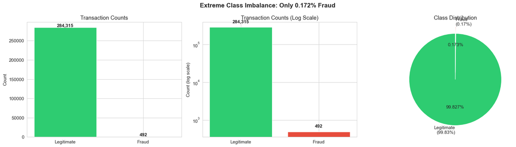

```python
fig, axes = plt.subplots(1, 3, figsize=(18, 5))

counts = df['Class'].value_counts()
colors = ['#2ecc71', '#e74c3c']
bars = axes[0].bar(['Legitimate', 'Fraud'], counts.values, color=colors)
axes[0].set_ylabel('Count')
axes[0].set_title('Transaction Counts')
for bar, val in zip(bars, counts.values):
    axes[0].text(bar.get_x() + bar.get_width() / 2, val + 2000,
                 f'{val:,}', ha='center', fontweight='bold', fontsize=11)

axes[1].bar(['Legitimate', 'Fraud'], counts.values, color=colors)
axes[1].set_yscale('log')
axes[1].set_ylabel('Count (log scale)')
axes[1].set_title('Transaction Counts (Log Scale)')
for i, val in enumerate(counts.values):
    axes[1].text(i, val * 1.3, f'{val:,}', ha='center', fontweight='bold')

axes[2].pie(counts.values, labels=['Legitimate\n(99.83%)', 'Fraud\n(0.17%)'],
            colors=colors, startangle=90, explode=(0, 0.15),
            autopct='%1.3f%%', textprops={'fontsize': 11})
axes[2].set_title('Class Distribution')

plt.suptitle('Extreme Class Imbalance: Only 0.172% Fraud',
             fontsize=15, fontweight='bold')
plt.tight_layout()
plt.show()
```

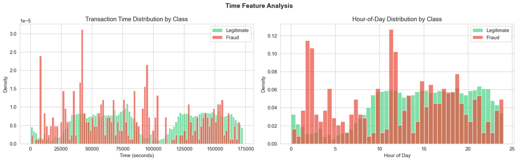

```python
fig, axes = plt.subplots(1, 2, figsize=(16, 5))

axes[0].hist(df[df['Class'] == 0]['Time'], bins=100, alpha=0.6,
             color='#2ecc71', label='Legitimate', density=True)
axes[0].hist(df[df['Class'] == 1]['Time'], bins=100, alpha=0.7,
             color='#e74c3c', label='Fraud', density=True)
axes[0].set_xlabel('Time (seconds)')
axes[0].set_ylabel('Density')
axes[0].set_title('Transaction Time Distribution by Class')
axes[0].legend()

df['Hour'] = (df['Time'] / 3600) % 24
axes[1].hist(df[df['Class'] == 0]['Hour'], bins=48, alpha=0.6,
             color='#2ecc71', label='Legitimate', density=True)
axes[1].hist(df[df['Class'] == 1]['Hour'], bins=48, alpha=0.7,
             color='#e74c3c', label='Fraud', density=True)
axes[1].set_xlabel('Hour of Day')
axes[1].set_ylabel('Density')
axes[1].set_title('Hour-of-Day Distribution by Class')
axes[1].legend()

plt.suptitle('Time Feature Analysis', fontsize=14, fontweight='bold')
plt.tight_layout()
plt.show()

df.drop('Hour', axis=1, inplace=True)
```

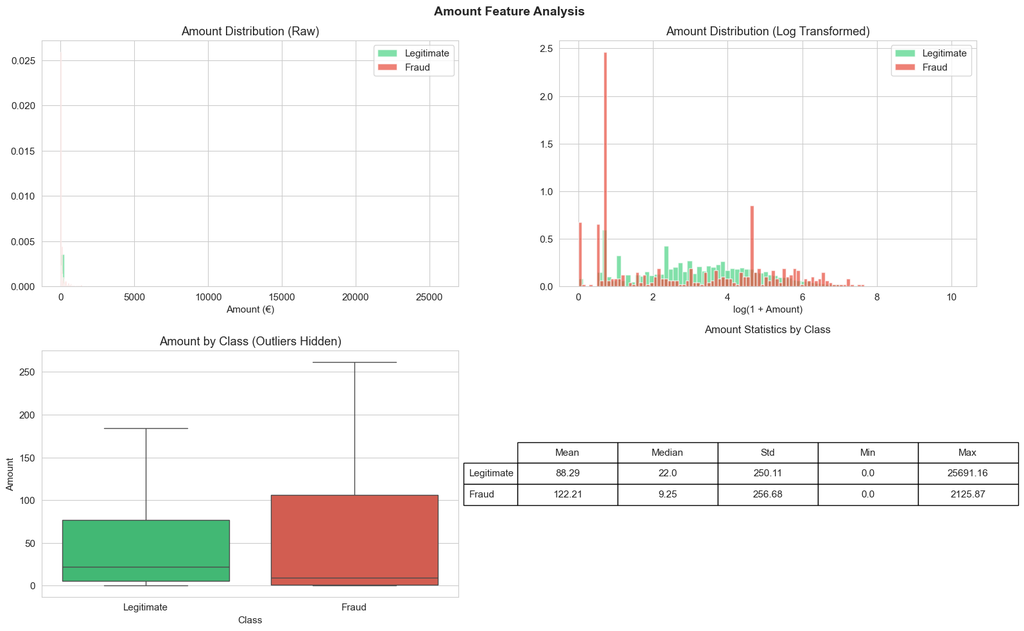

```
Amount statistics:
  Legitimate — Mean: €88.29, Median: €22.00
  Fraud      — Mean: €122.21, Median: €9.25
```

```python
fig, axes = plt.subplots(2, 2, figsize=(16, 10))

axes[0, 0].hist(df[df['Class'] == 0]['Amount'], bins=100, alpha=0.6,
                color='#2ecc71', label='Legitimate', density=True)
axes[0, 0].hist(df[df['Class'] == 1]['Amount'], bins=100, alpha=0.7,
                color='#e74c3c', label='Fraud', density=True)
axes[0, 0].set_xlabel('Amount (€)')
axes[0, 0].set_title('Amount Distribution (Raw)')
axes[0, 0].legend()

axes[0, 1].hist(np.log1p(df[df['Class'] == 0]['Amount']), bins=80, alpha=0.6,
                color='#2ecc71', label='Legitimate', density=True)
axes[0, 1].hist(np.log1p(df[df['Class'] == 1]['Amount']), bins=80, alpha=0.7,
                color='#e74c3c', label='Fraud', density=True)
axes[0, 1].set_xlabel('log(1 + Amount)')
axes[0, 1].set_title('Amount Distribution (Log Transformed)')
axes[0, 1].legend()

sns.boxplot(x='Class', y='Amount', data=df, ax=axes[1, 0],
            hue='Class', palette={0: '#2ecc71', 1: '#e74c3c'},
            showfliers=False, legend=False)
axes[1, 0].set_xticklabels(['Legitimate', 'Fraud'])
axes[1, 0].set_title('Amount by Class (Outliers Hidden)')

amount_stats = df.groupby('Class')['Amount'].describe()
axes[1, 1].axis('off')
table = axes[1, 1].table(
    cellText=amount_stats[['mean', '50%', 'std', 'min', 'max']].round(2).values,
    rowLabels=['Legitimate', 'Fraud'],
    colLabels=['Mean', 'Median', 'Std', 'Min', 'Max'],
    loc='center', cellLoc='center'
)
table.auto_set_font_size(False)
table.set_fontsize(11)
table.scale(1.2, 1.8)
axes[1, 1].set_title('Amount Statistics by Class', fontsize=12, pad=20)

plt.suptitle('Amount Feature Analysis', fontsize=14, fontweight='bold')
plt.tight_layout()
plt.show()

print(f"\nAmount statistics:")
print(f"  Legitimate — Mean: €{df[df['Class']==0]['Amount'].mean():.2f}, "
      f"Median: €{df[df['Class']==0]['Amount'].median():.2f}")
print(f"  Fraud      — Mean: €{df[df['Class']==1]['Amount'].mean():.2f}, "
      f"Median: €{df[df['Class']==1]['Amount'].median():.2f}")
```

```python
skew_kurt = pd.DataFrame({
    'Skewness': df.drop('Class', axis=1).apply(skew),
    'Kurtosis': df.drop('Class', axis=1).apply(kurtosis),
    '|Skewness|': df.drop('Class', axis=1).apply(lambda x: abs(skew(x))),
}).sort_values('|Skewness|', ascending=False)

print(skew_kurt.head(20).to_string())

print(f"\nFeatures with |skewness| > 2:  {(skew_kurt['|Skewness|'] > 2).sum()}")
print(f"Features with kurtosis > 10:   {(skew_kurt['Kurtosis'] > 10).sum()}")
print(f"Features with kurtosis > 100:  {(skew_kurt['Kurtosis'] > 100).sum()}")
```

```
        Skewness  Kurtosis  |Skewness|
Amount   16.9776  845.0778     16.9776
V28      11.1920  933.3811     11.1920
V8       -8.5219  220.5831      8.5219
V23      -5.8751  440.0809      5.8751
V2       -4.6248   95.7714      4.6248
V17      -3.8449   94.7980      3.8449
V21       3.5930  207.2834      3.5930
V1       -3.2807   32.4861      3.2807
V7        2.5539  405.6003      2.5539
V5       -2.4259  206.9009      2.4259
V12      -2.2784   20.2415      2.2784
V3       -2.2401   26.6191      2.2401
V20      -2.0371  271.0113      2.0371
V14      -1.9952   23.8790      1.9952
V6        1.8266   42.6417      1.8266
V10       1.1871   31.9877      1.1871
V27      -1.1702  244.9849      1.1702
V16      -1.1010   10.4189      1.1010
V4        0.6763    2.6354      0.6763
V26       0.5767    0.9190      0.5767

Features with |skewness| > 2:  13
Features with kurtosis > 10:   18
Features with kurtosis > 100:  9
```

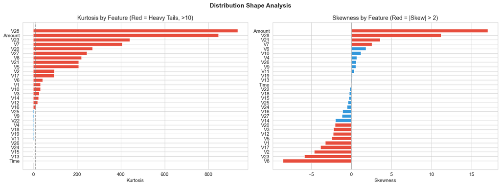

```python
fig, axes = plt.subplots(1, 2, figsize=(16, 6))

kurt_sorted = skew_kurt.sort_values('Kurtosis', ascending=False)
colors = ['#e74c3c' if k > 10 else '#3498db' for k in kurt_sorted['Kurtosis']]
axes[0].barh(kurt_sorted.index, kurt_sorted['Kurtosis'], color=colors)
axes[0].set_xlabel('Kurtosis')
axes[0].set_title('Kurtosis by Feature (Red = Heavy Tails, >10)')
axes[0].axvline(x=10, color='gray', linestyle='--', alpha=0.7)
axes[0].invert_yaxis()

skew_sorted = skew_kurt.sort_values('Skewness', ascending=False)
colors = ['#e74c3c' if abs(s) > 2 else '#3498db' for s in skew_sorted['Skewness']]
axes[1].barh(skew_sorted.index, skew_sorted['Skewness'], color=colors)
axes[1].set_xlabel('Skewness')
axes[1].set_title('Skewness by Feature (Red = |Skew| > 2)')
axes[1].axvline(x=0, color='gray', linestyle='-', alpha=0.5)
axes[1].invert_yaxis()

plt.suptitle('Distribution Shape Analysis', fontsize=14, fontweight='bold')
plt.tight_layout()
plt.show()
```

# 3. Expanded EDA — V-Features and Correlations

Since V1–V28 are PCA components, they are anonymous. However, we can still analyze which ones separate the fraud and legitimate classes, which ones have outliers, and whether the expected orthogonality holds.

```python
v_features = [f'V{i}' for i in range(1, 29)]

mean_diff = pd.DataFrame({
    'Legit_Mean': df[df['Class'] == 0][v_features].mean(),
    'Fraud_Mean': df[df['Class'] == 1][v_features].mean(),
    'Pooled_Std': df[v_features].std()
})
mean_diff['Standardized_Diff'] = (
    abs(mean_diff['Fraud_Mean'] - mean_diff['Legit_Mean']) / mean_diff['Pooled_Std']
)
mean_diff = mean_diff.sort_values('Standardized_Diff', ascending=False)

print(" V-Features Ranked by Class Separation \n")
print(mean_diff[['Standardized_Diff', 'Legit_Mean', 'Fraud_Mean']].to_string())
```

```
 V-Features Ranked by Class Separation

     Standardized_Diff  Legit_Mean  Fraud_Mean
V17             7.8619      0.0115     -6.6658
V14             7.2854      0.0121     -6.9717
V12             6.2752      0.0108     -6.2594
V10             5.2227      0.0098     -5.6769
V16             4.7328      0.0072     -4.1399
V3              4.6466      0.0122     -7.0333
V7              4.5093      0.0096     -5.5687
V11             3.7295     -0.0066      3.8002
V4              3.2135     -0.0079      4.5420
V18             2.6846      0.0039     -2.2463
V1              2.4405      0.0083     -4.7719
V9              2.3535      0.0045     -2.5811
V5              2.2870      0.0055     -3.1512
V2              2.1983     -0.0063      3.6238
V6              1.0510      0.0024     -1.3977
V21             0.9732     -0.0012      0.7136
V19             0.8376     -0.0012      0.6807
V20             0.4838     -0.0006      0.3723
V8              0.4786     -0.0010      0.5706
V27             0.4233     -0.0003      0.1706
V28             0.2296     -0.0001      0.0757
V24             0.1739      0.0002     -0.1051
V13             0.1100      0.0002     -0.1093
V26             0.1073     -0.0001      0.0516
V15             0.1017      0.0002     -0.0929
V25             0.0797     -0.0001      0.0414
V23             0.0647      0.0001     -0.0403
V22             0.0194     -0.0000      0.0140
```

## 3.2 VISUALIZATION: Top 8 V-Features by Class Separation

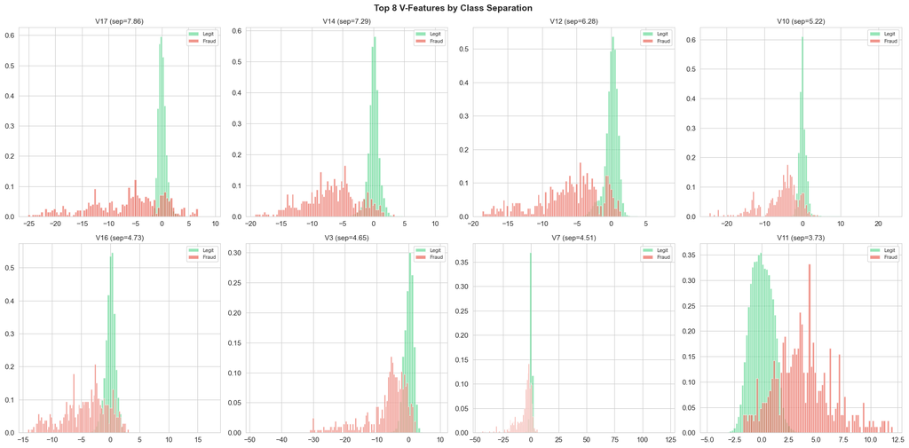

```python
top8 = mean_diff.head(8).index.tolist()

fig, axes = plt.subplots(2, 4, figsize=(20, 10))

for ax, feat in zip(axes.flatten(), top8):
    ax.hist(df[df['Class'] == 0][feat], bins=80, alpha=0.5,
            color='#2ecc71', label='Legit', density=True)
    ax.hist(df[df['Class'] == 1][feat], bins=80, alpha=0.6,
            color='#e74c3c', label='Fraud', density=True)
    diff = mean_diff.loc[feat, 'Standardized_Diff']
    ax.set_title(f'{feat} (sep={diff:.2f})', fontsize=11)
    ax.legend(fontsize=8)

plt.suptitle('Top 8 V-Features by Class Separation',
             fontsize=14, fontweight='bold')
plt.tight_layout()
plt.show()
```

### 3.3 VISUALIZATION: Bottom 4 V-Features (Least Useful)

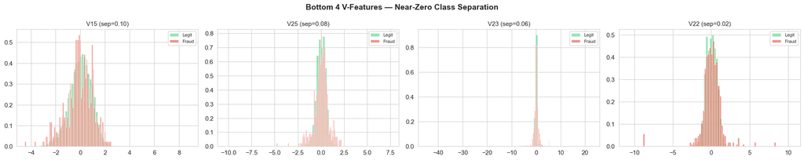

```python
bottom4 = mean_diff.tail(4).index.tolist()

fig, axes = plt.subplots(1, 4, figsize=(20, 4))

for ax, feat in zip(axes.flatten(), bottom4):
    ax.hist(df[df['Class'] == 0][feat], bins=80, alpha=0.5,
            color='#2ecc71', label='Legit', density=True)
    ax.hist(df[df['Class'] == 1][feat], bins=80, alpha=0.6,
            color='#e74c3c', label='Fraud', density=True)
    diff = mean_diff.loc[feat, 'Standardized_Diff']
    ax.set_title(f'{feat} (sep={diff:.2f})', fontsize=11)
    ax.legend(fontsize=8)

plt.suptitle('Bottom 4 V-Features — Near-Zero Class Separation',
             fontsize=14, fontweight='bold')
plt.tight_layout()
plt.show()
```

### Correlation matrix

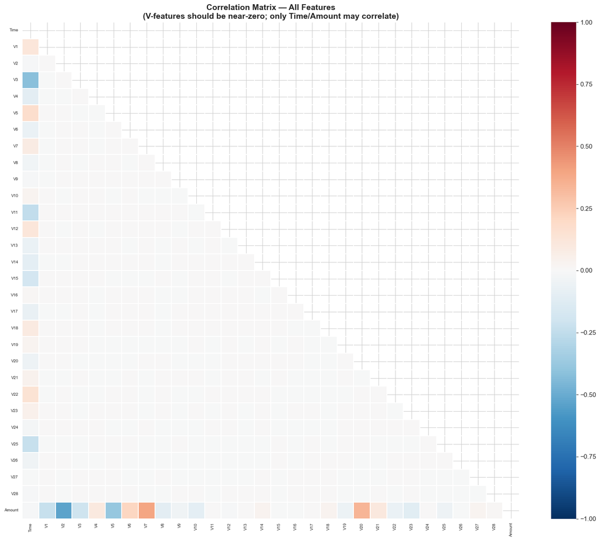

```
V-feature pairs with |correlation| > 0.3: 0
None
```

```python
corr_matrix = df.drop('Class', axis=1).corr()

plt.figure(figsize=(16, 13))
mask = np.triu(np.ones_like(corr_matrix, dtype=bool))
sns.heatmap(corr_matrix, mask=mask, cmap='RdBu_r', center=0,
            vmin=-1, vmax=1, linewidths=0.1, square=True,
            xticklabels=True, yticklabels=True)
plt.title('Correlation Matrix — All Features\n'
          '(V-features should be near-zero; only Time/Amount may correlate)',
          fontsize=14, fontweight='bold')
plt.xticks(fontsize=7, rotation=90)
plt.yticks(fontsize=7)
plt.tight_layout()
plt.show()

# Check for unexpected correlations among V-features
v_corr = df[v_features].corr()
upper_v = v_corr.where(np.triu(np.ones(v_corr.shape), k=1).astype(bool))
high_corr_v = [(col, upper_v.index[i], upper_v.iloc[i][col])
               for col in upper_v.columns
               for i in range(len(upper_v))
               if abs(upper_v.iloc[i][col]) > 0.3]

print(f"\nV-feature pairs with |correlation| > 0.3: {len(high_corr_v)}")
if high_corr_v:
    for f1, f2, r in sorted(high_corr_v, key=lambda x: abs(x[2]), reverse=True)[:5]:
        print(f"  {f1} ↔ {f2}: {r:.4f}")
else:
    print("None")
```

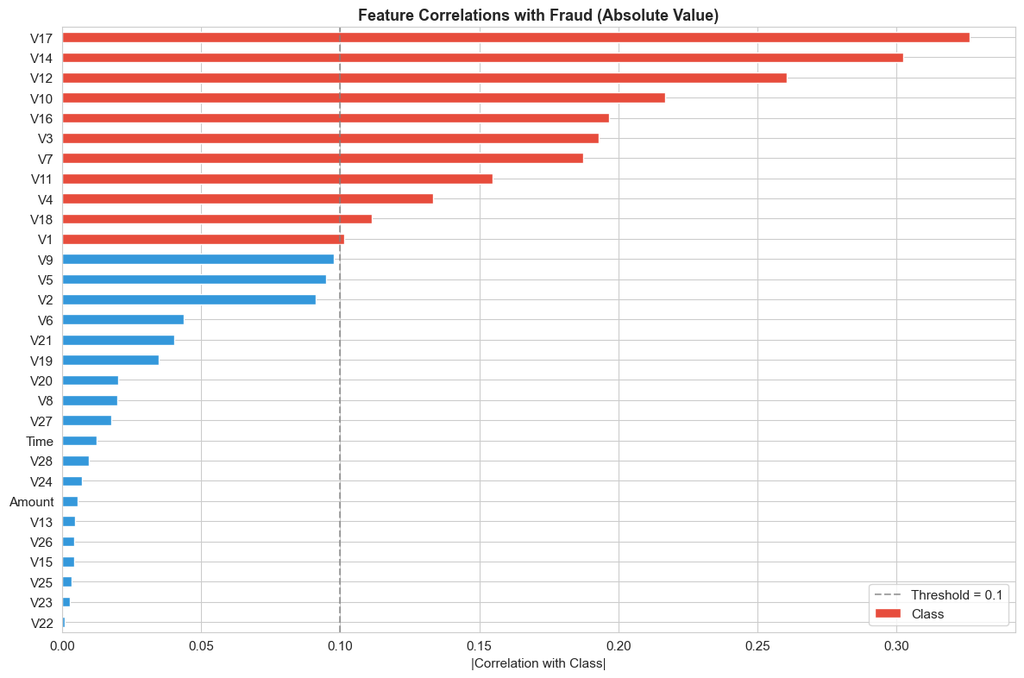

```
Top 10 features by |correlation| with fraud:
V17   0.3265
V14   0.3025
V12   0.2606
V10   0.2169
V16   0.1965
V3    0.1930
V7    0.1873
V11   0.1549
V4    0.1334
V18   0.1115
```

```python
target_corr = df.corr()['Class'].drop('Class').abs().sort_values(ascending=False)

fig, ax = plt.subplots(figsize=(12, 8))
colors = ['#e74c3c' if c > 0.1 else '#3498db' for c in target_corr.values]
target_corr.plot(kind='barh', ax=ax, color=colors)
ax.set_xlabel('|Correlation with Class|')
ax.set_title('Feature Correlations with Fraud (Absolute Value)',
             fontsize=13, fontweight='bold')
ax.axvline(x=0.1, color='gray', linestyle='--', alpha=0.7, label='Threshold = 0.1')
ax.legend()
ax.invert_yaxis()
plt.tight_layout()
plt.show()

print("\nTop 10 features by |correlation| with fraud:")
print(target_corr.head(10).to_string())
```

### Outlier analysis

```
Outlier Percentage by Feature (IQR × 3)

Amount   6.6505
V27      5.8018
V20      4.6997
V28      4.4146
V8       3.9623
V23      2.8563
V21      2.4346
V6       1.8922
V2       1.5635
V10      1.1264
V7       1.0713
V14      0.8444
V5       0.8149
V1       0.7001
V17      0.5088
```

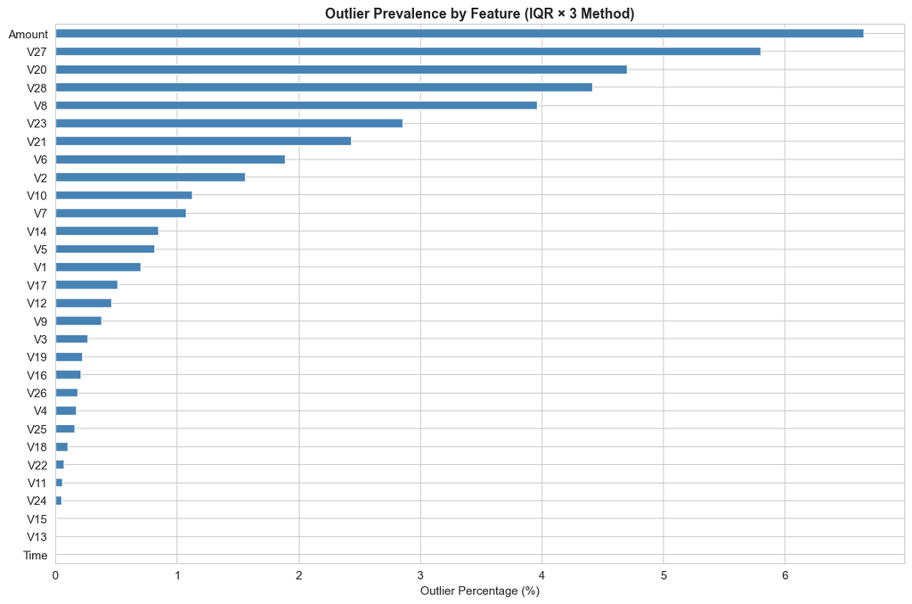

```python
outlier_pct = pd.Series(dtype=float)
for col in df.drop('Class', axis=1).columns:
    q1 = df[col].quantile(0.25)
    q3 = df[col].quantile(0.75)
    iqr_val = q3 - q1
    lower = q1 - 3 * iqr_val
    upper = q3 + 3 * iqr_val
    n_outliers = ((df[col] < lower) | (df[col] > upper)).sum()
    outlier_pct[col] = n_outliers / len(df) * 100

outlier_pct = outlier_pct.sort_values(ascending=False)

print("Outlier Percentage by Feature (IQR × 3)\n")
print(outlier_pct.head(15).to_string())

fig, ax = plt.subplots(figsize=(12, 8))
outlier_pct.plot(kind='barh', ax=ax, color='steelblue')
ax.set_xlabel('Outlier Percentage (%)')
ax.set_title('Outlier Prevalence by Feature (IQR × 3 Method)',
             fontsize=13, fontweight='bold')
ax.invert_yaxis()
plt.tight_layout()
plt.show()
```

```python
# 3.7  Duplicate Analysis
n_dupes = df.duplicated().sum()
print(f"Duplicate rows: {n_dupes}")

if n_dupes > 0:
    # Check if duplicates are more likely to be fraud
    dupes = df[df.duplicated(keep=False)]
    dupe_fraud_rate = dupes['Class'].mean() * 100
    overall_fraud_rate = df['Class'].mean() * 100

    print(f"\nFraud rate in duplicates:     {dupe_fraud_rate:.2f}%")
    print(f"Fraud rate overall:           {overall_fraud_rate:.4f}%")
    print(f"\nDuplicate rows likely represent repeated legitimate transactions")
    print(f"(e.g., same amount at same merchant). We keep them as they are")
    print(f"genuine data points, not data errors.")
else:
    print("No duplicate rows found.")
```

```
Duplicate rows: 1081

Fraud rate in duplicates:     1.73%
Fraud rate overall:           0.1727%

Duplicate rows likely represent repeated legitimate transactions
(e.g., same amount at same merchant). We keep them as they are
genuine data points, not data errors.
```

### Hypotheses about Fraud Drivers

1. Certain V-features (especially those with high class separation) will be the primary fraud indicators. The PCA transformation captured latent patterns; the top-separating components likely encode transaction velocity, geographic anomalies, or merchant category signals.
2. Transaction Amount alone is a weak predictor. Fraudulent transactions span a wide range of amounts. However, extremely small "test charges" (e.g., < €1) and unusually large transactions may be more suspicious.
3. Time-of-day patterns will provide modest additional signal. Fraud may concentrate during off-peak hours when human monitoring is reduced.

### Data Risks Identified

1. Extreme class imbalance (0.172%): Even worse than the bankruptcy dataset (3.2%). Accuracy is completely meaningless here; we must use PR-AUC, recall, and F1 for the minority class.
2. PCA anonymization limits feature engineering: We cannot create domain-driven composite features from V1–V28 because we don't know what they represent. Engineering is limited to Time and Amount.
3. Temporal structure: Transactions are time-ordered. A naive random split might leak future information. However, since PCA has already obscured the temporal features, and we are using stratify on the target, a random stratified split is acceptable for this dataset.

# 4. Data Preparation and Feature Engineering

## 4.1 Train / Validation / Test Split (70 / 10 / 20)

We split before any preprocessing to prevent data leakage. Stratification ensures the fraud rate is preserved across all partitions.

```python
X = df.drop('Class', axis=1)
y = df['Class']

X_temp, X_test, y_temp, y_test = train_test_split(
    X, y, test_size=0.20, random_state=SEED, stratify=y
)

X_train, X_val, y_train, y_val = train_test_split(
    X_temp, y_temp, test_size=0.125, random_state=SEED, stratify=y_temp
)

for name, X_part, y_part in [('Training', X_train, y_train),
                              ('Validation', X_val, y_val),
                              ('Test', X_test, y_test)]:
    n = len(y_part)
    n_fraud = y_part.sum()
    print(f"  {name:12s}: {n:>7,} rows ({n/len(df)*100:5.1f}%)  |  "
          f"Fraud: {n_fraud:>4} ({y_part.mean()*100:.4f}%)")

print(f"\n  Total:       {len(y_train)+len(y_val)+len(y_test):>7,}")
```

```
  Training    : 199,364 rows ( 70.0%)  |  Fraud:  345 (0.1731%)
  Validation  :  28,481 rows ( 10.0%)  |  Fraud:   49 (0.1720%)
  Test        :  56,962 rows ( 20.0%)  |  Fraud:   98 (0.1720%)

  Total:       284,807
```

## 4.2 Feature Engineering

Since V1–V28 are anonymous PCA components, our feature engineering is focused on the two interpretable features: Time and Amount.

```python
def engineer_features(data):
    data = data.copy()

    # 1. Hour of day (cyclical)
    # Time is seconds since first transaction; dataset spans ~2 days
    data['Hour'] = (data['Time'] / 3600) % 24

    # 2. Sin/Cos encoding of hour (captures cyclical nature)
    # WHY: Hour 23 is close to hour 0, but raw values are far apart.
    # Sin/cos encoding preserves this cyclical proximity.
    data['Hour_Sin'] = np.sin(2 * np.pi * data['Hour'] / 24)
    data['Hour_Cos'] = np.cos(2 * np.pi * data['Hour'] / 24)

    # 3. Is nighttime (off-peak hours: 11 PM - 6 AM)
    # WHY: Fraud may concentrate during off-peak hours.
    data['Is_Night'] = ((data['Hour'] >= 23) | (data['Hour'] < 6)).astype(int)

    # 4. Log-transformed Amount
    # WHY: Amount is extremely right-skewed (skewness ~16).
    # Log transform reduces skew and makes the distribution more normal,
    # which helps distance-based and split-based algorithms.
    data['Log_Amount'] = np.log1p(data['Amount'])

    # 5. Amount bins (small, medium, large, very large)
    # WHY: Captures non-linear relationship between amount and fraud risk.
    # Very small amounts may be "test charges" by fraudsters.
    # Bins are based on fixed thresholds, not data-dependent quantiles.
    data['Amount_Bin_Small'] = (data['Amount'] <= 5).astype(int)
    data['Amount_Bin_Large'] = (data['Amount'] > 500).astype(int)

    # Drop raw Hour (keep sin/cos representation)
    data.drop('Hour', axis=1, inplace=True)

    return data


X_train_eng = engineer_features(X_train)
X_val_eng = engineer_features(X_val)
X_test_eng = engineer_features(X_test)

new_cols = [c for c in X_train_eng.columns if c not in X_train.columns]
print(f"Engineered features: {new_cols}")
print(f"\nFeature count: {X_train.shape[1]} → {X_train_eng.shape[1]}")

print(f"\nEngineered feature statistics (training set):")
for col in new_cols:
    corr = np.corrcoef(X_train_eng[col], y_train)[0, 1]
    print(f"  {col:20s}  mean={X_train_eng[col].mean():.4f}  "
          f"std={X_train_eng[col].std():.4f}  corr_with_fraud={corr:.4f}")
```

```
Engineered features: ['Hour_Sin', 'Hour_Cos', 'Is_Night', 'Log_Amount', 'Amount_Bin_Small', 'Amount_Bin_Large']

Feature count: 30 → 36

Engineered feature statistics (training set):
  Hour_Sin              mean=-0.2673  std=0.6274  corr_with_fraud=0.0116
  Hour_Cos              mean=-0.1416  std=0.7175  corr_with_fraud=0.0056
  Is_Night              mean=0.1219  std=0.3272  corr_with_fraud=0.0206
  Log_Amount            mean=3.1527  std=1.6563  corr_with_fraud=-0.0087
  Amount_Bin_Small      mean=0.2424  std=0.4286  corr_with_fraud=0.0201
  Amount_Bin_Large      mean=0.0319  std=0.1757  corr_with_fraud=0.0096
```

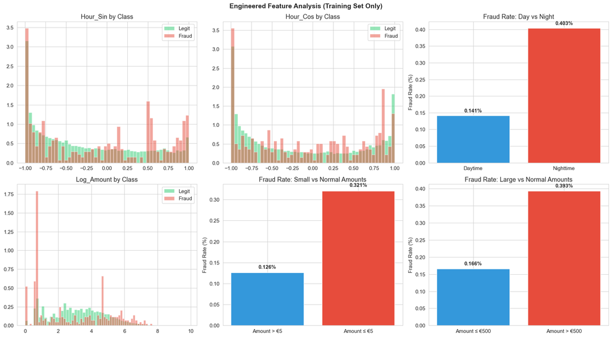

```python
fig, axes = plt.subplots(2, 3, figsize=(18, 10))

for label, color, name in [(0, '#2ecc71', 'Legit'), (1, '#e74c3c', 'Fraud')]:
    subset = X_train_eng.loc[y_train == label]
    axes[0, 0].hist(subset['Hour_Sin'], bins=50, alpha=0.5, color=color,
                    label=name, density=True)
axes[0, 0].set_title('Hour_Sin by Class')
axes[0, 0].legend()

for label, color, name in [(0, '#2ecc71', 'Legit'), (1, '#e74c3c', 'Fraud')]:
    subset = X_train_eng.loc[y_train == label]
    axes[0, 1].hist(subset['Hour_Cos'], bins=50, alpha=0.5, color=color,
                    label=name, density=True)
axes[0, 1].set_title('Hour_Cos by Class')
axes[0, 1].legend()

night_data = pd.DataFrame({
    'Is_Night': X_train_eng['Is_Night'],
    'Class': y_train.values
})
night_fraud = night_data.groupby('Is_Night')['Class'].mean() * 100
axes[0, 2].bar(['Daytime', 'Nighttime'], night_fraud.values,
               color=['#3498db', '#e74c3c'])
axes[0, 2].set_ylabel('Fraud Rate (%)')
axes[0, 2].set_title('Fraud Rate: Day vs Night')
for i, v in enumerate(night_fraud.values):
    axes[0, 2].text(i, v + 0.01, f'{v:.3f}%', ha='center', fontweight='bold')

for label, color, name in [(0, '#2ecc71', 'Legit'), (1, '#e74c3c', 'Fraud')]:
    subset = X_train_eng.loc[y_train == label]
    axes[1, 0].hist(subset['Log_Amount'], bins=60, alpha=0.5, color=color,
                    label=name, density=True)
axes[1, 0].set_title('Log_Amount by Class')
axes[1, 0].legend()

small_data = pd.DataFrame({
    'Small': X_train_eng['Amount_Bin_Small'],
    'Class': y_train.values
})
small_fraud = small_data.groupby('Small')['Class'].mean() * 100
axes[1, 1].bar(['Amount > €5', 'Amount ≤ €5'], small_fraud.values,
               color=['#3498db', '#e74c3c'])
axes[1, 1].set_ylabel('Fraud Rate (%)')
axes[1, 1].set_title('Fraud Rate: Small vs Normal Amounts')
for i, v in enumerate(small_fraud.values):
    axes[1, 1].text(i, v + 0.01, f'{v:.3f}%', ha='center', fontweight='bold')

large_data = pd.DataFrame({
    'Large': X_train_eng['Amount_Bin_Large'],
    'Class': y_train.values
})
large_fraud = large_data.groupby('Large')['Class'].mean() * 100
axes[1, 2].bar(['Amount ≤ €500', 'Amount > €500'], large_fraud.values,
               color=['#3498db', '#e74c3c'])
axes[1, 2].set_ylabel('Fraud Rate (%)')
axes[1, 2].set_title('Fraud Rate: Large vs Normal Amounts')
for i, v in enumerate(large_fraud.values):
    axes[1, 2].text(i, v + 0.01, f'{v:.3f}%', ha='center', fontweight='bold')

plt.suptitle('Engineered Feature Analysis (Training Set Only)',
             fontsize=14, fontweight='bold')
plt.tight_layout()
plt.show()
```

## 4.3 Outlier Treatment: Winsorization of Amount

The V-features are PCA components and their outliers are meaningful (they encode extreme transaction patterns). We only winsorize Amount because it has extreme right skew (skewness 16) and the max (€25,691) is orders of magnitude above the median (€22).

Winsorization caps are computed on training data only.

```python
amount_lower = X_train_eng['Amount'].quantile(0.001)
amount_upper = X_train_eng['Amount'].quantile(0.999)

print(f"Amount winsorization caps (from training):")
print(f"  Lower (0.1th pct): €{amount_lower:.2f}")
print(f"  Upper (99.9th pct): €{amount_upper:.2f}")
print(f"  Training Amount range before: €{X_train_eng['Amount'].min():.2f} — "
      f"€{X_train_eng['Amount'].max():.2f}")

for data in [X_train_eng, X_val_eng, X_test_eng]:
    data['Amount'] = data['Amount'].clip(lower=amount_lower, upper=amount_upper)

print(f"  Training Amount range after:  €{X_train_eng['Amount'].min():.2f} — "
      f"€{X_train_eng['Amount'].max():.2f}")

print(f"\nAmount skewness before winsorization: "
      f"{skew(X_train['Amount']):.2f}")
print(f"Amount skewness after winsorization:  "
      f"{skew(X_train_eng['Amount']):.2f}")
print(f"Log_Amount skewness:                  "
      f"{skew(X_train_eng['Log_Amount']):.2f}")
```

```
Amount winsorization caps (from training):
  Lower (0.1th pct): €0.00
  Upper (99.9th pct): €2929.93
  Training Amount range before: €0.00 — €19656.53
  Training Amount range after:  €0.00 — €2929.93

Amount skewness before winsorization: 14.83
Amount skewness after winsorization:  6.81
Log_Amount skewness:                  0.16
```

## 4.4 Scaling Strategy

We use RobustScaler for Amount and Time because it is less sensitive to outliers than StandardScaler. Scaler is fit on training data only.

```python
features_to_scale = ['Amount', 'Time', 'Log_Amount']

scaler = RobustScaler()
X_train_eng[features_to_scale] = scaler.fit_transform(X_train_eng[features_to_scale])
X_val_eng[features_to_scale] = scaler.transform(X_val_eng[features_to_scale])
X_test_eng[features_to_scale] = scaler.transform(X_test_eng[features_to_scale])

print(f"\nScaled features: {features_to_scale}")
print(f"\nTraining statistics after scaling:")
for col in features_to_scale:
    print(f"  {col:15s}: mean={X_train_eng[col].mean():.4f}, "
          f"std={X_train_eng[col].std():.4f}, "
          f"median={X_train_eng[col].median():.4f}")

print(f"\nV-features (not scaled) — sample statistics:")
for col in ['V1', 'V14', 'V17']:
    print(f"  {col:15s}: mean={X_train_eng[col].mean():.4f}, "
          f"std={X_train_eng[col].std():.4f}")
```

```
Scaled features: ['Amount', 'Time', 'Log_Amount']

Training statistics after scaling:
  Amount         : mean=0.8980, std=2.9545, median=0.0000
  Time           : mean=0.1177, std=0.5576, median=0.0000
  Log_Amount     : mean=0.0070, std=0.6685, median=0.0000

V-features (not scaled) — sample statistics:
  V1             : mean=0.0004, std=1.9602
  V14            : mean=-0.0005, std=0.9574
  V17            : mean=-0.0000, std=0.8472
```

## 4.5 Near-Zero Variance Check

```python
variance = X_train_eng.var().sort_values()
low_var = variance[variance < 1e-6]

print(f"Features with near-zero variance: {len(low_var)}")
if len(low_var) > 0:
    print(low_var.to_string())
    # Drop them
    drop_cols = low_var.index.tolist()
    X_train_eng.drop(columns=drop_cols, inplace=True)
    X_val_eng.drop(columns=drop_cols, inplace=True)
    X_test_eng.drop(columns=drop_cols, inplace=True)
    print(f"\nDropped: {drop_cols}")
else:
    print("All features have sufficient variance. ")

print(f"\nFinal feature count: {X_train_eng.shape[1]}")
```

```
Features with near-zero variance: 0
All features have sufficient variance.

Final feature count: 36
```

## 4.6 Final Dataset Overview and Validation

```python
print(f"\n  Training:   {X_train_eng.shape}")
print(f"  Validation: {X_val_eng.shape}")
print(f"  Test:       {X_test_eng.shape}")

print(f"\n  Missing values (train): {X_train_eng.isnull().sum().sum()}")
print(f"  Missing values (val):   {X_val_eng.isnull().sum().sum()}")
print(f"  Missing values (test):  {X_test_eng.isnull().sum().sum()}")

print(f"\n  Infinite values (train): {np.isinf(X_train_eng).sum().sum()}")

for data in [X_train_eng, X_val_eng, X_test_eng]:
    data.replace([np.inf, -np.inf], np.nan, inplace=True)
    data.fillna(0, inplace=True)

print(f"  After cleanup — Missing: {X_train_eng.isnull().sum().sum()}, "
      f"Inf: {np.isinf(X_train_eng).sum().sum()}")

print(f"\n  All dtypes numeric: "
      f"{all(X_train_eng.dtypes.apply(lambda x: np.issubdtype(x, np.number)))}")

print(f"\n  Features: {X_train_eng.columns.tolist()}")
```

```
  Training:   (199364, 36)
  Validation: (28481, 36)
  Test:       (56962, 36)

  Missing values (train): 0
  Missing values (val):   0
  Missing values (test):  0

  Infinite values (train): 0
  After cleanup — Missing: 0, Inf: 0

  All dtypes numeric: True

  Features: ['Time', 'V1', 'V2', 'V3', 'V4', 'V5', 'V6', 'V7', 'V8', 'V9', 'V10', 'V11', 'V12', 'V13', 'V14', 'V15', 'V16', 'V17', 'V18', 'V19', 'V20', 'V21', 'V22', 'V23', 'V24', 'V25', 'V26', 'V27', 'V28', 'Amount', 'Hour_Sin', 'Hour_Cos', 'Is_Night', 'Log_Amount', 'Amount_Bin_Small', 'Amount_Bin_…
```

```python
feature_summary = pd.DataFrame({
    'Feature': X_train_eng.columns,
    'Mean': X_train_eng.mean().values,
    'Std': X_train_eng.std().values,
    'Min': X_train_eng.min().values,
    'Max': X_train_eng.max().values,
    'Skewness': X_train_eng.apply(skew).values,
    'Kurtosis': X_train_eng.apply(kurtosis).values,
    'Corr_with_Fraud': [np.corrcoef(X_train_eng[c], y_train)[0, 1]
                         for c in X_train_eng.columns]
}).set_index('Feature')

feature_summary['|Corr|'] = feature_summary['Corr_with_Fraud'].abs()
feature_summary = feature_summary.sort_values('|Corr|', ascending=False)

print(feature_summary.to_string())
```

```
                    Mean    Std      Min     Max  Skewness  Kurtosis  Corr_with_Fraud  |Corr|
Feature
V17              -0.0000 0.8472 -25.1628  9.2535   -3.7694   92.3857          -0.3322  0.3322
V14              -0.0005 0.9574 -19.2143 10.5268   -1.9958   24.1685          -0.3049  0.3049
V12               0.0018 0.9978 -18.4311  7.8484   -2.3003   20.6843          -0.2643  0.2643
V10              -0.0002 1.0894 -24.5883 23.7451    1.0768   33.3161          -0.2233  0.2233
V3               -0.0026 1.5176 -33.6810  9.3826   -2.1854   24.1460          -0.2024  0.2024
V16               0.0001 0.8735 -14.1299  7.0591   -1.1269    9.9152          -0.1986  0.1986
V7                0.0006 1.2182 -43.5572 36.6773   -1.1189   96.5084          -0.1985  0.1985
V11              -0.0008 1.0194  -4.6829 12.0189    0.3617    1.7401           0.1558  0.1558
V4               -0.0015 1.4162  -5.6832 16.8753    0.6824    2.7057           0.1382  0.1382
V18              -0.0010 0.8390  -9.4987  5.0411   -0.2624    2.5748          -0.1138  0.1138
V1                0.0004 1.9602 -56.4075  2.4519   -3.2645   32.1747          -0.1062  0.1062
V9                0.0007 1.0987 -13.4341 15.5950    0.5348    3.7873          -0.1028  0.1028
V5               -0.0000 1.3627 -42.1479 34.8017   -0.3850   46.7750          -0.1016  0.1016
V2               -0.0000 1.6486 -72.7157 22.0577   -4.7599  104.9061           0.0951  0.0951
V6               -0.0032 1.3220 -26.1605 22.5293    1.2217   10.9088          -0.0435  0.0435
V21               0.0016 0.7314 -34.8304 27.2028    3.4275  207.5619           0.0355  0.0355
V19              -0.0004 0.8128  -7.2135  5.5721    0.1033    1.7200           0.0329  0.0329
Is_Night          0.1219 0.3272   0.0000  1.0000    2.3110    3.3408           0.0206  0.0206
Amount_Bin_Small  0.2424 0.4286   0.0000  1.0000    1.2020   -0.5551           0.0201  0.0201
V20              -0.0007 0.7586 -25.2223 39.4209   -0.0602  198.1961           0.0191  0.0191
V8               -0.0002 1.1943 -73.2167 20.0072   -8.7712  236.5084           0.0183  0.0183
V27               0.0002 0.3988 -22.5657 11.1357   -3.2363  133.2181           0.0151  0.0151
Hour_Sin         -0.2673 0.6274  -1.0000  1.0000    0.5367   -1.0374           0.0116  0.0116
Time              0.1177 0.5576  -0.9969  1.0321   -0.0387   -1.2946          -0.0108  0.0108
Amount_Bin_Large  0.0319 0.1757   0.0000  1.0000    5.3286   26.3943           0.0096  0.0096
Log_Amount        0.0070 0.6685  -1.2656  2.7248    0.1593   -0.6461          -0.0087  0.0087
V13              -0.0006 0.9943  -5.7919  4.5690    0.0647    0.1836          -0.0076  0.0076
Amount            0.8980 2.9545  -0.3059 40.4385    6.8086   64.5943           0.0075  0.0075
V24              -0.0005 0.6043  -2.8366  4.0163   -0.5569    0.5899          -0.0075  0.0075
V28              -0.0002 0.3247 -11.7109 33.8478   10.6719  998.4433           0.0068  0.0068
Hour_Cos         -0.1416 0.7175  -1.0000  1.0000    0.3071   -1.4607           0.0056  0.0056
V15               0.0002 0.9146  -4.4989  5.7845   -0.3152    0.2492          -0.0047  0.0047
V26              -0.0001 0.4817  -2.6046  3.5173    0.5753    0.9115           0.0041  0.0041
V22               0.0020 0.7252 -10.9331 10.5031   -0.2112    2.7964           0.0034  0.0034
V23               0.0004 0.6123 -36.6660 22.5284   -3.7235  344.4902          -0.0021  0.0021
V25               0.0002 0.5206  -7.0813  6.0709   -0.3759    3.5523           0.0004  0.0004
```

# 5. Comparison: Original vs Prepared Data

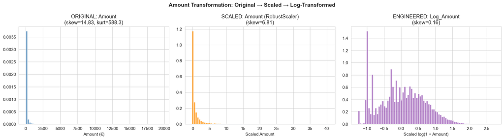

```python
fig, axes = plt.subplots(1, 3, figsize=(18, 5))

axes[0].hist(X_train['Amount'], bins=80, color='steelblue', alpha=0.7, density=True)
axes[0].set_title(f'ORIGINAL: Amount\n(skew={skew(X_train["Amount"]):.2f},'
                  f' kurt={kurtosis(X_train["Amount"]):.1f})')
axes[0].set_xlabel('Amount (€)')

axes[1].hist(X_train_eng['Amount'], bins=80, color='darkorange', alpha=0.7, density=True)
axes[1].set_title(f'SCALED: Amount (RobustScaler)\n'
                  f'(skew={skew(X_train_eng["Amount"]):.2f})')
axes[1].set_xlabel('Scaled Amount')

axes[2].hist(X_train_eng['Log_Amount'], bins=80, color='#9b59b6', alpha=0.7, density=True)
axes[2].set_title(f'ENGINEERED: Log_Amount\n'
                  f'(skew={skew(X_train_eng["Log_Amount"]):.2f})')
axes[2].set_xlabel('Scaled log(1 + Amount)')

plt.suptitle('Amount Transformation: Original → Scaled → Log-Transformed',
             fontsize=14, fontweight='bold')
plt.tight_layout()
plt.show()
```

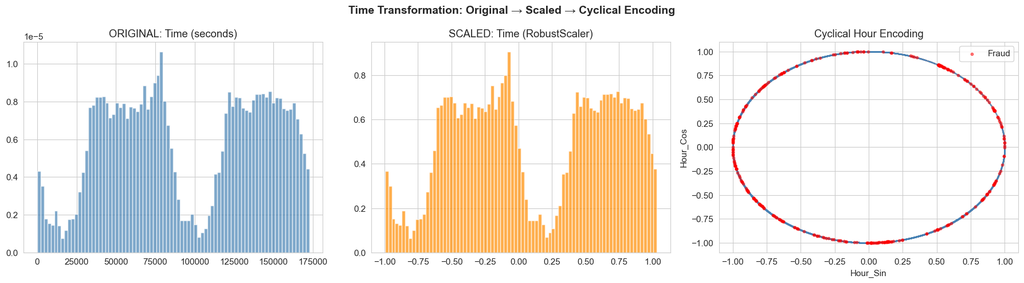

```python
fig, axes = plt.subplots(1, 3, figsize=(18, 5))

axes[0].hist(X_train['Time'], bins=80, color='steelblue', alpha=0.7, density=True)
axes[0].set_title('ORIGINAL: Time (seconds)')

axes[1].hist(X_train_eng['Time'], bins=80, color='darkorange', alpha=0.7, density=True)
axes[1].set_title('SCALED: Time (RobustScaler)')

axes[2].scatter(X_train_eng['Hour_Sin'], X_train_eng['Hour_Cos'],
                alpha=0.01, s=1, color='steelblue')
fraud_mask = y_train == 1
axes[2].scatter(X_train_eng.loc[fraud_mask, 'Hour_Sin'],
                X_train_eng.loc[fraud_mask, 'Hour_Cos'],
                alpha=0.5, s=10, color='red', label='Fraud')
axes[2].set_xlabel('Hour_Sin')
axes[2].set_ylabel('Hour_Cos')
axes[2].set_title('Cyclical Hour Encoding')
axes[2].legend()

plt.suptitle('Time Transformation: Original → Scaled → Cyclical Encoding',
             fontsize=14, fontweight='bold')
plt.tight_layout()
plt.show()
```

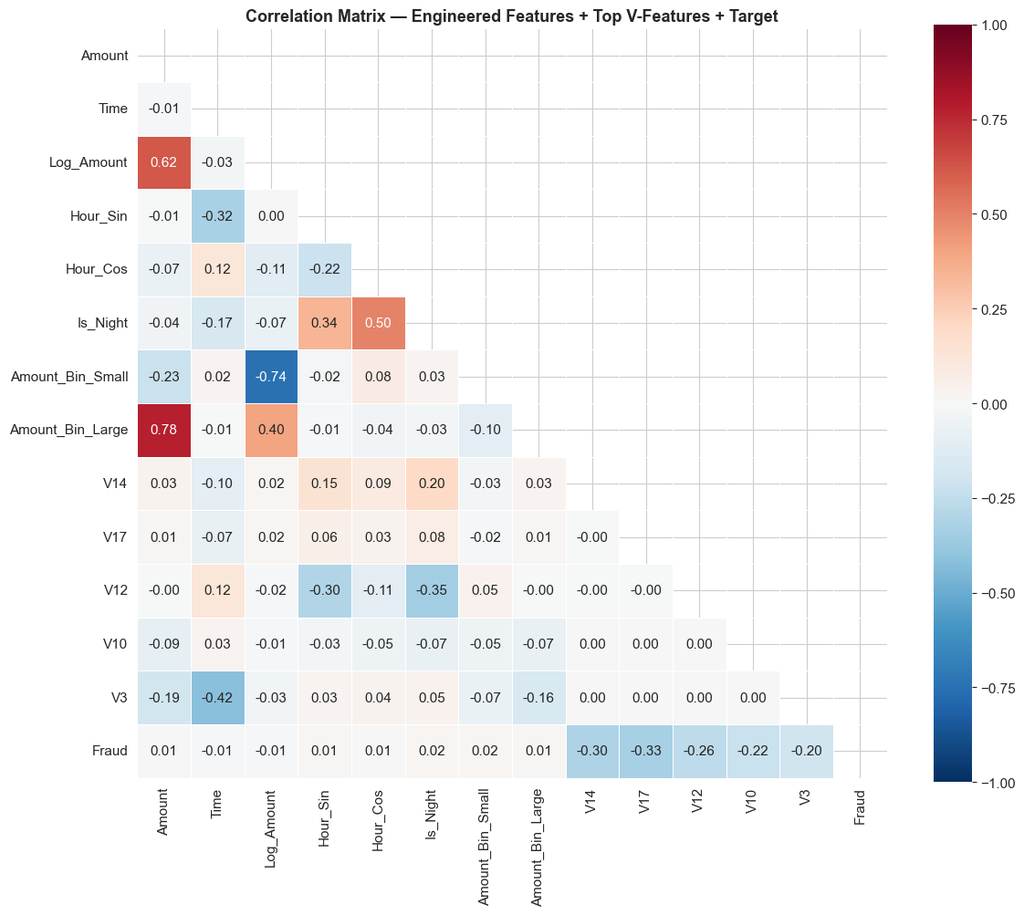

```python
eng_features = ['Amount', 'Time', 'Log_Amount', 'Hour_Sin', 'Hour_Cos',
                'Is_Night', 'Amount_Bin_Small', 'Amount_Bin_Large']
eng_features = [f for f in eng_features if f in X_train_eng.columns]

top_v = ['V14', 'V17', 'V12', 'V10', 'V3']
plot_cols = eng_features + top_v

corr_final = X_train_eng[plot_cols].copy()
corr_final['Fraud'] = y_train.values
corr_matrix_final = corr_final.corr()

plt.figure(figsize=(12, 10))
mask = np.triu(np.ones_like(corr_matrix_final, dtype=bool))
sns.heatmap(corr_matrix_final, mask=mask, annot=True, fmt='.2f',
            cmap='RdBu_r', center=0, vmin=-1, vmax=1,
            linewidths=0.5, square=True)
plt.title('Correlation Matrix — Engineered Features + Top V-Features + Target',
          fontsize=13, fontweight='bold')
plt.tight_layout()
plt.show()
```

# 6. Data Leakage Prevention Checklist

| Check | Status |
| --- | --- |
| Data split performed before any preprocessing | done |
| Winsorization caps computed on training data only | done |
| RobustScaler fit on training data only, then `.transform()` on val/test | done |
| Feature engineering uses only element-wise operations(no fitting) | done |
| Bin thresholds are fixed constants (€5, €500), not data-dependent | done |
| Target variable `Class` is never used as a feature or in any transformation | done |
| Fraud rates are consistent across train/val/test (~0.172%) | done |
| No future transactions leak into past (stratified random split) | done |
| V1–V28 PCA features are not re-scaled (already standardized) | done |

# 7. Data Ready for Modeling

The following objects are prepared and ready for model training:

| Object | Shape | Description |
| --- | --- | --- |
| `X_train_eng` | (train_rows, features) | Training features, preprocessed |
| `y_train` | (train_rows,) | Training labels |
| `X_val_eng` | (val_rows, features) | Validation features, preprocessed |
| `y_val` | (val_rows,) | Validation labels |
| `X_test_eng` | (test_rows, features) | Test features, preprocessed (untouched until final eval) |
| `y_test` | (test_rows,) | Test labels |

### Preprocessing Summary

1. **Split:** 70 / 10 / 20 stratified split
2. **Feature engineering:** Hour_Sin, Hour_Cos, Is_Night, Log_Amount, Amount_Bin_Small, Amount_Bin_Large (6 new features)
3. **Winsorization:** Amount capped at 0.1st and 99.9th percentile (training)
4. **Scaling:** RobustScaler on Amount, Time, Log_Amount (fit on training only)
5. **V1–V28:** Untouched (PCA-standardized, orthogonal)
6. **No multicollinearity removal:** Not needed for PCA components
7. **No encoding:** All features are numeric

### Recommended Modeling Approach

- **Primary metric:** PR-AUC (Average Precision) — the 0.172% fraud rate makes accuracy meaningless and ROC-AUC misleadingly optimistic.
- **Class balancing:** Use `class_weight='balanced'` or SMOTE/undersampling.
- **Cross-validation:** StratifiedKFold (5 or 10 folds) to preserve class ratios.

> **Note:** Full Chicago-style references are consolidated in the final section of this notebook.

# 8. Baseline Model: Majority Class Classifier

Before training any real model, we establish a floor. A classifier that always predicts "legitimate" will achieve ~99.83% accuracy — proving accuracy is meaningless for this problem.

```python
dummy = DummyClassifier(strategy='most_frequent', random_state=SEED)
dummy.fit(X_train_eng, y_train)
y_pred_dummy = dummy.predict(X_val_eng)

print(classification_report(y_val, y_pred_dummy, target_names=['Legitimate', 'Fraud']))
print(f"Accuracy:  {dummy.score(X_val_eng, y_val):.4f}  ← looks great, means nothing")
print(f"F1 (Fraud): {f1_score(y_val, y_pred_dummy, pos_label=1):.4f}  ← zero")
print(f"PR-AUC:     {average_precision_score(y_val, dummy.predict_proba(X_val_eng)[:,1]):.4f}  ← baseline")
```

```
              precision    recall  f1-score   support

  Legitimate       1.00      1.00      1.00     28432
       Fraud       0.00      0.00      0.00        49

    accuracy                           1.00     28481
   macro avg       0.50      0.50      0.50     28481
weighted avg       1.00      1.00      1.00     28481

Accuracy:  0.9983  ← looks great, means nothing
F1 (Fraud): 0.0000  ← zero
PR-AUC:     0.0017  ← baseline
```

# 9. Random Forest — Cross-Validation & Hyperparameter Tuning

## 9.1 Why Random Forest?

Random Forest is an ensemble of decision trees trained on bootstrap samples with random feature subsets.  
For fraud detection it offers several advantages:

- **Handles class imbalance** via `class_weight='balanced'`, which reweights each sample inversely  
  proportional to its class frequency so the minority fraud class gets ~578× more influence.
- **Non-linear** — can capture complex interactions between PCA components without manual feature  
  engineering.
- **Robust to outliers** — decision splits are rank-based, so extreme values in Amount/V-features  
  do not distort the model.
- **Built-in feature importance** — out-of-bag impurity-based importance reveals which PCA components  
  and engineered features drive fraud detection.

## 9.2 Hyperparameter Explanation

| Parameter | Value Searched | Why |
| --- | --- | --- |
| `n_estimators` | 100, 200, 300 | More trees → lower variance but diminishing returns; 200–300 is typically the sweet spot for tabular data |
| `max_depth` | 10, 15, 20, None | Controls over-fitting; unlimited depth risks memorising the 492 fraud samples |
| `min_samples_leaf` | 1, 2, 4 | Minimum samples at a leaf; higher values smooth decision boundaries |
| `class_weight` | 'balanced' (fixed) | Corrects the 1:578 imbalance without any resampling; fit on training data only |

```python
# 5-fold Stratified CV (preserves 0.172% fraud rate in every fold)
cv_outer = StratifiedKFold(n_splits=5, shuffle=True, random_state=SEED)

scoring = {
    'pr_auc'   : make_scorer(average_precision_score, needs_proba=True),
    'f1'       : make_scorer(f1_score, pos_label=1, zero_division=0),
    'roc_auc'  : 'roc_auc',
    'recall'   : 'recall',
    'precision': 'precision',
}

# Hyperparameter search space
rf_param_dist = {
    'clf__n_estimators'   : [100, 200, 300],
    'clf__max_depth'      : [10, 15, 20, None],
    'clf__min_samples_leaf': [1, 2, 4],
}

rf_pipeline = Pipeline([
    ('clf', RandomForestClassifier(
        class_weight='balanced',
        random_state=SEED,
        n_jobs=-1
    ))
])

rf_search = RandomizedSearchCV(
    estimator   = rf_pipeline,
    param_distributions = rf_param_dist,
    n_iter      = 20,           # 20 random configs × 5 folds = 100 fits
    scoring     = 'average_precision',
    cv          = cv_outer,
    refit       = True,
    n_jobs      = -1,
    random_state= SEED,
    verbose     = 1,
)

print("Starting Random Forest hyperparameter search (RandomizedSearchCV)...")
t0 = time.time()
rf_search.fit(X_train_eng, y_train)
rf_time = time.time() - t0

print(f"\nSearch completed in {rf_time:.1f}s")
print(f"Best CV PR-AUC : {rf_search.best_score_:.4f}")
print(f"Best params    : {rf_search.best_params_}")
```

```
Starting Random Forest hyperparameter search (RandomizedSearchCV)...
Fitting 5 folds for each of 20 candidates, totalling 100 fits

Search completed in 727.1s
Best CV PR-AUC : 0.8529
Best params    : {'clf__n_estimators': 300, 'clf__min_samples_leaf': 1, 'clf__max_depth': None}
```

## 9.3 Cross-Validation Results

We extract all 20 candidate configurations from the search and plot how CV PR-AUC varies  
across the hyperparameter grid — helping us understand sensitivity to each parameter.

```
Top 10 configurations by CV PR-AUC:
```

|  | param_clf__n_estimators | param_clf__max_depth | param_clf__min_samples_leaf | mean_test_score | std_test_score | mean_fit_time |
| --- | --- | --- | --- | --- | --- | --- |
| 14 | 300 | None | 1 | 0.8529 | 0.0505 | 149.0777 |
| 16 | 200 | 20 | 1 | 0.8502 | 0.0514 | 104.2825 |
| 5 | 200 | None | 2 | 0.8500 | 0.0576 | 98.1856 |
| 3 | 100 | None | 2 | 0.8494 | 0.0551 | 56.2680 |
| 10 | 100 | 15 | 1 | 0.8473 | 0.0555 | 62.9942 |
| 6 | 100 | 20 | 2 | 0.8472 | 0.0581 | 63.4349 |
| 18 | 300 | 15 | 1 | 0.8456 | 0.0541 | 134.1403 |
| 15 | 100 | 15 | 4 | 0.8453 | 0.0528 | 61.3510 |
| 11 | 200 | None | 4 | 0.8444 | 0.0529 | 102.7695 |
| 7 | 100 | 15 | 2 | 0.8442 | 0.0592 | 52.3670 |

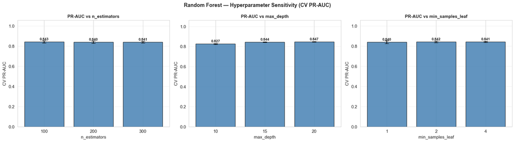

```python
rf_cv_df = pd.DataFrame(rf_search.cv_results_)
rf_cv_df = rf_cv_df.sort_values('mean_test_score', ascending=False)

print("Top 10 configurations by CV PR-AUC:")
cols = ['param_clf__n_estimators', 'param_clf__max_depth',
        'param_clf__min_samples_leaf',
        'mean_test_score', 'std_test_score', 'mean_fit_time']
display(rf_cv_df[cols].head(10).round(4))

fig, axes = plt.subplots(1, 3, figsize=(18, 5))
for ax, param, label in zip(
    axes,
    ['param_clf__n_estimators', 'param_clf__max_depth', 'param_clf__min_samples_leaf'],
    ['n_estimators', 'max_depth', 'min_samples_leaf']
):
    tmp = rf_cv_df.copy()
    tmp[param] = tmp[param].astype(str)
    grouped = tmp.groupby(param)['mean_test_score'].agg(['mean', 'std']).reset_index()
    bars = ax.bar(grouped[param], grouped['mean'], yerr=grouped['std'],
                  capsize=5, alpha=0.85, color='steelblue', edgecolor='black')
    ax.set_xlabel(label, fontsize=11)
    ax.set_ylabel('CV PR-AUC', fontsize=11)
    ax.set_title(f'PR-AUC vs {label}', fontsize=11, fontweight='bold')
    ax.set_ylim(0, grouped['mean'].max() * 1.22 + 0.03)
    ax.grid(axis='y', alpha=0.3)
    for bar, val in zip(bars, grouped['mean'].values):
        ax.text(bar.get_x() + bar.get_width() / 2,
                bar.get_height() + 0.007,
                f'{val:.3f}', ha='center', va='bottom', fontsize=9, fontweight='bold')

plt.suptitle('Random Forest — Hyperparameter Sensitivity (CV PR-AUC)',
             fontsize=13, fontweight='bold')
plt.tight_layout()
plt.show()
```

## 9.4 Full Cross-Validation on Best Configuration

We now run full 5-fold CV on the best pipeline to report per-fold metrics with  
train/val gap — diagnosing potential overfitting.

```
Random Forest (Best Params) — 5-Fold Stratified CV

Metric         Train Mean  Train Std   Val Mean  Val Std      Gap
--------------------------------------------------------------
pr_auc             1.0000     0.0000     0.8529   0.0505   0.1471
f1                 1.0000     0.0000     0.8402   0.0502   0.1598
roc_auc            1.0000     0.0000     0.9612   0.0210   0.0388
recall             1.0000     0.0000     0.7536   0.0855   0.2464
precision          1.0000     0.0000     0.9566   0.0094   0.0434
```

|  | Fold | Train PR-AUC | Val PR-AUC | Train F1 | Val F1 | Val Recall | Val Precision |
| --- | --- | --- | --- | --- | --- | --- | --- |
| 0 | 1 | 1.0000 | 0.8700 | 1.0000 | 0.8067 | 0.6957 | 0.9600 |
| 1 | 2 | 1.0000 | 0.7578 | 1.0000 | 0.7863 | 0.6667 | 0.9583 |
| 2 | 3 | 1.0000 | 0.8486 | 1.0000 | 0.8067 | 0.6957 | 0.9600 |
| 3 | 4 | 1.0000 | 0.8962 | 1.0000 | 0.8906 | 0.8261 | 0.9661 |
| 4 | 5 | 1.0000 | 0.8921 | 1.0000 | 0.9104 | 0.8841 | 0.9385 |

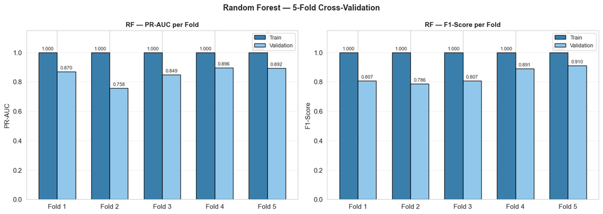

```python
best_rf = rf_search.best_estimator_


_scoring_no_pr = {
    'f1'       : make_scorer(f1_score, pos_label=1, zero_division=0),
    'roc_auc'  : 'roc_auc',
    'recall'   : 'recall',
    'precision': 'precision',
}
cv_results_rf = cross_validate(
    best_rf, X_train_eng, y_train,
    cv=cv_outer, scoring=_scoring_no_pr,
    return_train_score=True, n_jobs=-1
)


_pr_train, _pr_val = [], []
for tr_idx, va_idx in cv_outer.split(X_train_eng, y_train):
    Xtr, Xva = X_train_eng.iloc[tr_idx], X_train_eng.iloc[va_idx]
    ytr, yva = y_train.iloc[tr_idx],     y_train.iloc[va_idx]
    best_rf.fit(Xtr, ytr)
    _pr_train.append(average_precision_score(ytr, best_rf.predict_proba(Xtr)[:, 1]))
    _pr_val.append(  average_precision_score(yva, best_rf.predict_proba(Xva)[:, 1]))
cv_results_rf['train_pr_auc'] = np.array(_pr_train)
cv_results_rf['test_pr_auc']  = np.array(_pr_val)

best_rf.fit(X_train_eng, y_train)

print("\nRandom Forest (Best Params) — 5-Fold Stratified CV\n")
print(f"{'Metric':<12} {'Train Mean':>12} {'Train Std':>10} {'Val Mean':>10} {'Val Std':>8} {'Gap':>8}")
print("-" * 62)
for m in ['pr_auc', 'f1', 'roc_auc', 'recall', 'precision']:
    tr = cv_results_rf[f'train_{m}']
    va = cv_results_rf[f'test_{m}']
    print(f"{m:<12} {tr.mean():>12.4f} {tr.std():>10.4f} {va.mean():>10.4f} {va.std():>8.4f} {tr.mean()-va.mean():>8.4f}")

fold_df_rf = pd.DataFrame({
    'Fold'         : np.arange(1, 6),
    'Train PR-AUC' : cv_results_rf['train_pr_auc'].round(4),
    'Val PR-AUC'   : cv_results_rf['test_pr_auc'].round(4),
    'Train F1'     : cv_results_rf['train_f1'].round(4),
    'Val F1'       : cv_results_rf['test_f1'].round(4),
    'Val Recall'   : cv_results_rf['test_recall'].round(4),
    'Val Precision': cv_results_rf['test_precision'].round(4),
})
print(); display(fold_df_rf)

fig, axes = plt.subplots(1, 2, figsize=(14, 5))
x = np.arange(5); w = 0.35
for ax, (metric, title) in zip(axes, [('pr_auc', 'PR-AUC'), ('f1', 'F1-Score')]):
    b1 = ax.bar(x - w/2, cv_results_rf[f'train_{metric}'], w,
                label='Train', color='#2471a3', edgecolor='black', alpha=0.9)
    b2 = ax.bar(x + w/2, cv_results_rf[f'test_{metric}'],  w,
                label='Validation', color='#85c1e9', edgecolor='black', alpha=0.9)
    ax.set_xticks(x); ax.set_xticklabels([f'Fold {i+1}' for i in range(5)])
    ax.set_ylim(0, 1.15); ax.set_ylabel(title, fontsize=11)
    ax.set_title(f'RF — {title} per Fold', fontsize=11, fontweight='bold')
    ax.legend(fontsize=9); ax.grid(axis='y', alpha=0.3)
    for bar in list(b1) + list(b2):
        ax.text(bar.get_x() + bar.get_width() / 2, bar.get_height() + 0.01,
                f'{bar.get_height():.3f}', ha='center', va='bottom', fontsize=8)

plt.suptitle('Random Forest — 5-Fold Cross-Validation', fontsize=13, fontweight='bold')
plt.tight_layout(); plt.show()
```

## 9.5 Validation-Set Evaluation (Best Model)

After hyperparameter tuning we evaluate the best model on the held-out validation set,  
including threshold optimisation for maximum F1.

```
Optimal threshold : 0.4800

              precision    recall  f1-score   support

       Legit     0.9995    0.9999    0.9997     28432
       Fraud     0.9459    0.7143    0.8140        49

    accuracy                         0.9994     28481
   macro avg     0.9727    0.8571    0.9068     28481
weighted avg     0.9994    0.9994    0.9994     28481
```

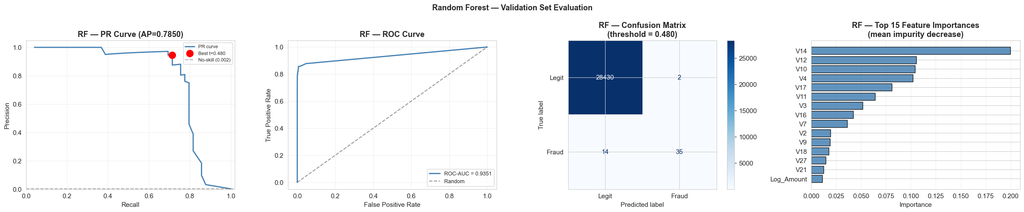

```
Val PR-AUC   : 0.7850
Val ROC-AUC  : 0.9351
Val F1       : 0.8140
Val Recall   : 0.7143
Val Precision: 0.9459
Training time: 727.1s
```

```python
best_rf.fit(X_train_eng, y_train)
y_val_proba_rf = best_rf.predict_proba(X_val_eng)[:, 1]

prec_rf, rec_rf, thr_rf = precision_recall_curve(y_val, y_val_proba_rf)
f1_thr_rf    = 2 * prec_rf[:-1] * rec_rf[:-1] / (prec_rf[:-1] + rec_rf[:-1] + 1e-8)
best_idx_rf  = int(np.argmax(f1_thr_rf))
best_thr_rf  = thr_rf[best_idx_rf]
y_val_pred_rf = (y_val_proba_rf >= best_thr_rf).astype(int)

print(f"Optimal threshold : {best_thr_rf:.4f}")
print(f"\n{classification_report(y_val, y_val_pred_rf, target_names=['Legit','Fraud'], digits=4)}")

fig, axes = plt.subplots(1, 4, figsize=(24, 5))


axes[0].plot(rec_rf[:-1], prec_rf[:-1], lw=2, color='steelblue', label='PR curve')
axes[0].scatter(rec_rf[best_idx_rf], prec_rf[best_idx_rf],
                s=130, c='red', zorder=6, label=f'Best t={best_thr_rf:.3f}')
axes[0].axhline(y_val.mean(), color='gray', ls='--', alpha=0.6,
                label=f'No-skill ({y_val.mean():.3f})')
axes[0].set_xlabel('Recall'); axes[0].set_ylabel('Precision')
axes[0].set_title(f'RF — PR Curve (AP={average_precision_score(y_val, y_val_proba_rf):.4f})',
                  fontweight='bold')
axes[0].legend(fontsize=8); axes[0].grid(True, alpha=0.3)
axes[0].set_xlim(0, 1.02); axes[0].set_ylim(0, 1.05)

fpr_rf, tpr_rf, _ = roc_curve(y_val, y_val_proba_rf)
axes[1].plot(fpr_rf, tpr_rf, lw=2, color='steelblue',
             label=f'ROC-AUC = {roc_auc_score(y_val, y_val_proba_rf):.4f}')
axes[1].plot([0, 1], [0, 1], 'k--', alpha=0.4, label='Random')
axes[1].set_xlabel('False Positive Rate'); axes[1].set_ylabel('True Positive Rate')
axes[1].set_title('RF — ROC Curve', fontweight='bold')
axes[1].legend(fontsize=9); axes[1].grid(True, alpha=0.3)


cm_rf = confusion_matrix(y_val, y_val_pred_rf)
ConfusionMatrixDisplay(cm_rf, display_labels=['Legit', 'Fraud']).plot(
    cmap='Blues', ax=axes[2], values_format='d')
axes[2].set_title(f'RF — Confusion Matrix\n(threshold = {best_thr_rf:.3f})',
                  fontweight='bold')


rf_imp = pd.Series(best_rf.named_steps['clf'].feature_importances_,
                   index=X_train_eng.columns).sort_values(ascending=True).tail(15)
axes[3].barh(rf_imp.index, rf_imp.values, color='steelblue', edgecolor='black', alpha=0.85)
axes[3].set_title('RF — Top 15 Feature Importances\n(mean impurity decrease)',
                  fontweight='bold')
axes[3].set_xlabel('Importance')
axes[3].grid(axis='x', alpha=0.3)

plt.suptitle('Random Forest — Validation Set Evaluation', fontsize=13, fontweight='bold')
plt.tight_layout(); plt.show()

rf_val_pr_auc  = average_precision_score(y_val, y_val_proba_rf)
rf_val_roc_auc = roc_auc_score(y_val, y_val_proba_rf)
print(f"\nVal PR-AUC   : {rf_val_pr_auc:.4f}")
print(f"Val ROC-AUC  : {rf_val_roc_auc:.4f}")
print(f"Val F1       : {f1_score(y_val, y_val_pred_rf):.4f}")
print(f"Val Recall   : {recall_score(y_val, y_val_pred_rf):.4f}")
print(f"Val Precision: {precision_score(y_val, y_val_pred_rf):.4f}")
print(f"Training time: {rf_time:.1f}s")
```

# 10. Logistic Regression — Cross-Validation & Hyperparameter Tuning

## 10.1 Why Logistic Regression?

Logistic Regression is the standard interpretable linear baseline for binary classification.  
Despite its simplicity, it performs well on PCA-transformed features because:

- V1–V28 are **orthogonal and already centred** — exactly the conditions where logistic regression  
  thrives (no multicollinearity, no need for non-linear interactions among V-features).
- It produces **calibrated probabilities** natively, making threshold optimisation straightforward.
- Coefficients are directly interpretable: which PCA components and engineered features have the  
  strongest linear association with fraud?

## 10.2 Hyperparameter Explanation

[output not shown]

```python
lr_param_grid = {
    'clf__C'      : [0.001, 0.01, 0.1, 1, 10, 100],
    'clf__penalty': ['l1', 'l2'],
    'clf__solver' : ['liblinear'],   # supports both L1 and L2
}

lr_pipeline = Pipeline([
    ('clf', LogisticRegression(
        class_weight='balanced',
        max_iter=2000,
        random_state=SEED
    ))
])

lr_search = GridSearchCV(
    estimator = lr_pipeline,
    param_grid = lr_param_grid,
    scoring   = 'average_precision',
    cv        = cv_outer,
    refit     = True,
    n_jobs    = -1,
    verbose   = 1,
)

print("Starting Logistic Regression grid search (GridSearchCV)...")
t0 = time.time()
lr_search.fit(X_train_eng, y_train)
lr_time = time.time() - t0

print(f"\nSearch completed in {lr_time:.1f}s")
print(f"Best CV PR-AUC : {lr_search.best_score_:.4f}")
print(f"Best params    : {lr_search.best_params_}")
```

```
Starting Logistic Regression grid search (GridSearchCV)...
Fitting 5 folds for each of 12 candidates, totalling 60 fits

Search completed in 260.9s
Best CV PR-AUC : 0.7800
Best params    : {'clf__C': 0.01, 'clf__penalty': 'l2', 'clf__solver': 'liblinear'}
```

## 10.3 Cross-Validation Results — Regularisation Sensitivity

```
Top 10 configurations by CV PR-AUC:
```

|  | param_clf__C | param_clf__penalty | param_clf__solver | mean_test_score | std_test_score | mean_fit_time |
| --- | --- | --- | --- | --- | --- | --- |
| 3 | 0.0100 | l2 | liblinear | 0.7800 | 0.0401 | 6.1225 |
| 5 | 0.1000 | l2 | liblinear | 0.7787 | 0.0396 | 8.6762 |
| 2 | 0.0100 | l1 | liblinear | 0.7785 | 0.0403 | 8.1090 |
| 4 | 0.1000 | l1 | liblinear | 0.7784 | 0.0394 | 102.2299 |
| 7 | 1.0000 | l2 | liblinear | 0.7766 | 0.0391 | 10.1965 |
| 6 | 1.0000 | l1 | liblinear | 0.7766 | 0.0389 | 169.7923 |
| 10 | 100.0000 | l1 | liblinear | 0.7766 | 0.0388 | 126.8493 |
| 9 | 10.0000 | l2 | liblinear | 0.7766 | 0.0388 | 10.8119 |
| 11 | 100.0000 | l2 | liblinear | 0.7766 | 0.0388 | 11.4214 |
| 8 | 10.0000 | l1 | liblinear | 0.7766 | 0.0388 | 176.9354 |

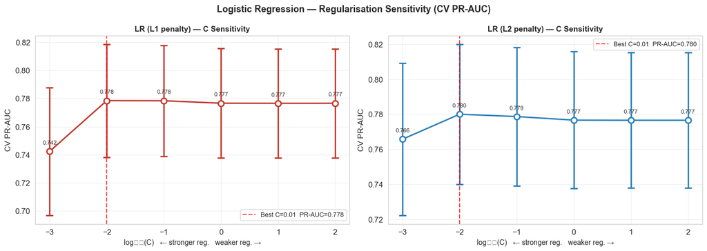

```python
lr_cv_df = pd.DataFrame(lr_search.cv_results_)
lr_cv_df['param_clf__C'] = lr_cv_df['param_clf__C'].astype(float)

print("Top 10 configurations by CV PR-AUC:")
cols_lr = ['param_clf__C', 'param_clf__penalty', 'param_clf__solver',
           'mean_test_score', 'std_test_score', 'mean_fit_time']
display(lr_cv_df.sort_values('mean_test_score', ascending=False)[cols_lr].head(10).round(4))

fig, axes = plt.subplots(1, 2, figsize=(14, 5))
for ax, (penalty, color) in zip(axes, [('l1', '#c0392b'), ('l2', '#2980b9')]):
    sub = lr_cv_df[lr_cv_df['param_clf__penalty'] == penalty].sort_values('param_clf__C')
    ax.errorbar(np.log10(sub['param_clf__C']),
                sub['mean_test_score'], yerr=sub['std_test_score'],
                marker='o', lw=2, capsize=5, color=color,
                markerfacecolor='white', markeredgewidth=2, markersize=8)
    ax.set_xlabel('log₁₀(C)   ← stronger reg.   weaker reg. →', fontsize=10)
    ax.set_ylabel('CV PR-AUC', fontsize=11)
    ax.set_title(f'LR ({penalty.upper()} penalty) — C Sensitivity', fontsize=11, fontweight='bold')
    ax.grid(True, alpha=0.3)
    best_row = sub.loc[sub['mean_test_score'].idxmax()]
    ax.axvline(np.log10(best_row['param_clf__C']), color='red', ls='--', alpha=0.7,
               label=f"Best C={best_row['param_clf__C']}  PR-AUC={best_row['mean_test_score']:.3f}")
    ax.legend(fontsize=9)
    for _, row in sub.iterrows():
        ax.annotate(f"{row['mean_test_score']:.3f}",
                    (np.log10(row['param_clf__C']), row['mean_test_score']),
                    textcoords='offset points', xytext=(0, 10), ha='center', fontsize=8)

plt.suptitle('Logistic Regression — Regularisation Sensitivity (CV PR-AUC)',
             fontsize=13, fontweight='bold')
plt.tight_layout(); plt.show()
```

## 10.4 Full Cross-Validation on Best Configuration

```
Logistic Regression (Best Params) — 5-Fold Stratified CV

Metric         Train Mean  Train Std   Val Mean  Val Std      Gap
--------------------------------------------------------------
pr_auc             0.7664     0.0140     0.7668   0.0439  -0.0004
f1                 0.1249     0.0144     0.1215   0.0078   0.0034
roc_auc            0.9933     0.0012     0.9855   0.0087   0.0078
recall             0.9362     0.0104     0.9130   0.0389   0.0232
precision          0.0670     0.0083     0.0651   0.0046   0.0018
```

|  | Fold | Train PR-AUC | Val PR-AUC | Train F1 | Val F1 | Val Recall | Val Precision |
| --- | --- | --- | --- | --- | --- | --- | --- |
| 0 | 1 | 0.7650 | 0.7604 | 0.1190 | 0.1260 | 0.9275 | 0.0676 |
| 1 | 2 | 0.7907 | 0.7005 | 0.1524 | 0.1302 | 0.8406 | 0.0706 |
| 2 | 3 | 0.7511 | 0.8280 | 0.1251 | 0.1266 | 0.9130 | 0.0680 |
| 3 | 4 | 0.7706 | 0.7461 | 0.1156 | 0.1152 | 0.9565 | 0.0613 |
| 4 | 5 | 0.7545 | 0.7989 | 0.1125 | 0.1096 | 0.9275 | 0.0582 |

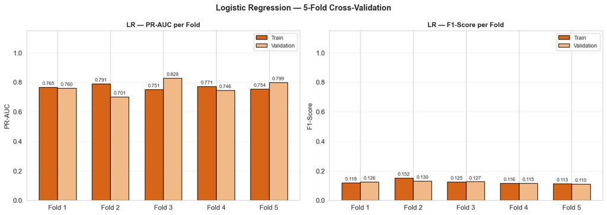

```python
best_lr = lr_search.best_estimator_

_scoring_no_pr = {
    'f1'       : make_scorer(f1_score, pos_label=1, zero_division=0),
    'roc_auc'  : 'roc_auc',
    'recall'   : 'recall',
    'precision': 'precision',
}
cv_results_lr = cross_validate(
    best_lr, X_train_eng, y_train,
    cv=cv_outer, scoring=_scoring_no_pr,
    return_train_score=True, n_jobs=-1
)

_pr_train_lr, _pr_val_lr = [], []
for tr_idx, va_idx in cv_outer.split(X_train_eng, y_train):
    Xtr, Xva = X_train_eng.iloc[tr_idx], X_train_eng.iloc[va_idx]
    ytr, yva = y_train.iloc[tr_idx],     y_train.iloc[va_idx]
    best_lr.fit(Xtr, ytr)
    _pr_train_lr.append(average_precision_score(ytr, best_lr.predict_proba(Xtr)[:, 1]))
    _pr_val_lr.append(  average_precision_score(yva, best_lr.predict_proba(Xva)[:, 1]))
cv_results_lr['train_pr_auc'] = np.array(_pr_train_lr)
cv_results_lr['test_pr_auc']  = np.array(_pr_val_lr)
best_lr.fit(X_train_eng, y_train)

print("Logistic Regression (Best Params) — 5-Fold Stratified CV\n")
print(f"{'Metric':<12} {'Train Mean':>12} {'Train Std':>10} {'Val Mean':>10} {'Val Std':>8} {'Gap':>8}")
print("-" * 62)
for m in ['pr_auc', 'f1', 'roc_auc', 'recall', 'precision']:
    tr = cv_results_lr[f'train_{m}']
    va = cv_results_lr[f'test_{m}']
    print(f"{m:<12} {tr.mean():>12.4f} {tr.std():>10.4f} {va.mean():>10.4f} {va.std():>8.4f} {tr.mean()-va.mean():>8.4f}")

fold_df_lr = pd.DataFrame({
    'Fold'         : np.arange(1, 6),
    'Train PR-AUC' : cv_results_lr['train_pr_auc'].round(4),
    'Val PR-AUC'   : cv_results_lr['test_pr_auc'].round(4),
    'Train F1'     : cv_results_lr['train_f1'].round(4),
    'Val F1'       : cv_results_lr['test_f1'].round(4),
    'Val Recall'   : cv_results_lr['test_recall'].round(4),
    'Val Precision': cv_results_lr['test_precision'].round(4),
})
display(fold_df_lr)

fig, axes = plt.subplots(1, 2, figsize=(14, 5))
x = np.arange(5); w = 0.35
for ax, (metric, title) in zip(axes, [('pr_auc', 'PR-AUC'), ('f1', 'F1-Score')]):
    b1 = ax.bar(x - w/2, cv_results_lr[f'train_{metric}'], w,
                label='Train', color='#d35400', edgecolor='black', alpha=0.9)
    b2 = ax.bar(x + w/2, cv_results_lr[f'test_{metric}'],  w,
                label='Validation', color='#f0b27a', edgecolor='black', alpha=0.9)
    ax.set_xticks(x); ax.set_xticklabels([f'Fold {i+1}' for i in range(5)])
    ax.set_ylim(0, 1.15); ax.set_ylabel(title, fontsize=11)
    ax.set_title(f'LR — {title} per Fold', fontsize=11, fontweight='bold')
    ax.legend(fontsize=9); ax.grid(axis='y', alpha=0.3)
    for bar in list(b1) + list(b2):
        ax.text(bar.get_x() + bar.get_width() / 2, bar.get_height() + 0.01,
                f'{bar.get_height():.3f}', ha='center', va='bottom', fontsize=8)

plt.suptitle('Logistic Regression — 5-Fold Cross-Validation', fontsize=13, fontweight='bold')
plt.tight_layout(); plt.show()
```

## 10.5 Validation-Set Evaluation (Best Model)

```
Optimal threshold : 0.9998

              precision    recall  f1-score   support

       Legit     0.9995    0.9997    0.9996     28432
       Fraud     0.8182    0.7347    0.7742        49

    accuracy                         0.9993     28481
   macro avg     0.9089    0.8672    0.8869     28481
weighted avg     0.9992    0.9993    0.9992     28481
```

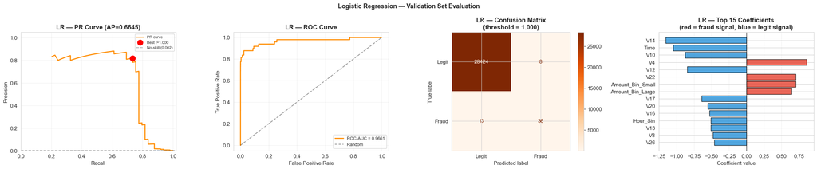

```
Val PR-AUC   : 0.6645
Val ROC-AUC  : 0.9661
Val F1       : 0.7742
Val Recall   : 0.7347
Val Precision: 0.8182
Training time: 260.9s
```

```python
best_lr.fit(X_train_eng, y_train)
y_val_proba_lr = best_lr.predict_proba(X_val_eng)[:, 1]

prec_lr, rec_lr, thr_lr = precision_recall_curve(y_val, y_val_proba_lr)
f1_thr_lr    = 2 * prec_lr[:-1] * rec_lr[:-1] / (prec_lr[:-1] + rec_lr[:-1] + 1e-8)
best_idx_lr  = int(np.argmax(f1_thr_lr))
best_thr_lr  = thr_lr[best_idx_lr]
y_val_pred_lr = (y_val_proba_lr >= best_thr_lr).astype(int)

print(f"Optimal threshold : {best_thr_lr:.4f}")
print(f"\n{classification_report(y_val, y_val_pred_lr, target_names=['Legit','Fraud'], digits=4)}")

fig, axes = plt.subplots(1, 4, figsize=(24, 5))

# 1. PR
axes[0].plot(rec_lr[:-1], prec_lr[:-1], lw=2, color='darkorange', label='PR curve')
axes[0].scatter(rec_lr[best_idx_lr], prec_lr[best_idx_lr],
                s=130, c='red', zorder=6, label=f'Best t={best_thr_lr:.3f}')
axes[0].axhline(y_val.mean(), color='gray', ls='--', alpha=0.6,
                label=f'No-skill ({y_val.mean():.3f})')
axes[0].set_xlabel('Recall'); axes[0].set_ylabel('Precision')
axes[0].set_title(f'LR — PR Curve (AP={average_precision_score(y_val, y_val_proba_lr):.4f})',
                  fontweight='bold')
axes[0].legend(fontsize=8); axes[0].grid(True, alpha=0.3)
axes[0].set_xlim(0, 1.02); axes[0].set_ylim(0, 1.05)

# 2. ROC
fpr_lr, tpr_lr, _ = roc_curve(y_val, y_val_proba_lr)
axes[1].plot(fpr_lr, tpr_lr, lw=2, color='darkorange',
             label=f'ROC-AUC = {roc_auc_score(y_val, y_val_proba_lr):.4f}')
axes[1].plot([0, 1], [0, 1], 'k--', alpha=0.4, label='Random')
axes[1].set_xlabel('False Positive Rate'); axes[1].set_ylabel('True Positive Rate')
axes[1].set_title('LR — ROC Curve', fontweight='bold')
axes[1].legend(fontsize=9); axes[1].grid(True, alpha=0.3)


cm_lr = confusion_matrix(y_val, y_val_pred_lr)
ConfusionMatrixDisplay(cm_lr, display_labels=['Legit', 'Fraud']).plot(
    cmap='Oranges', ax=axes[2], values_format='d')
axes[2].set_title(f'LR — Confusion Matrix\n(threshold = {best_thr_lr:.3f})', fontweight='bold')


lr_coef = pd.Series(
    best_lr.named_steps['clf'].coef_[0],
    index=X_train_eng.columns
).sort_values(key=abs, ascending=True).tail(15)
coef_colors = ['#e74c3c' if v > 0 else '#3498db' for v in lr_coef.values]
axes[3].barh(lr_coef.index, lr_coef.values, color=coef_colors, edgecolor='black', alpha=0.85)
axes[3].axvline(0, color='black', lw=0.8)
axes[3].set_title('LR — Top 15 Coefficients\n(red = fraud signal, blue = legit signal)',
                  fontweight='bold')
axes[3].set_xlabel('Coefficient value')
axes[3].grid(axis='x', alpha=0.3)

plt.suptitle('Logistic Regression — Validation Set Evaluation', fontsize=13, fontweight='bold')
plt.tight_layout(); plt.show()

lr_val_pr_auc  = average_precision_score(y_val, y_val_proba_lr)
lr_val_roc_auc = roc_auc_score(y_val, y_val_proba_lr)
print(f"\nVal PR-AUC   : {lr_val_pr_auc:.4f}")
print(f"Val ROC-AUC  : {lr_val_roc_auc:.4f}")
print(f"Val F1       : {f1_score(y_val, y_val_pred_lr):.4f}")
print(f"Val Recall   : {recall_score(y_val, y_val_pred_lr):.4f}")
print(f"Val Precision: {precision_score(y_val, y_val_pred_lr):.4f}")
print(f"Training time: {lr_time:.1f}s")
```

# 11. XGBoost — Cross-Validation & Hyperparameter Tuning

## 11.1 Why XGBoost?

XGBoost (Extreme Gradient Boosting) builds an ensemble of trees **sequentially**, each tree  
correcting the residual errors of the previous one. For fraud detection:

- **Native imbalance handling** via `scale_pos_weight` — equivalent to class_weight='balanced'  
  but integrated directly into the gradient computation.
- **Second-order gradients** (Newton's method) — converges faster and more accurately than  
  first-order methods (Random Forest uses entropy/gini).
- **Regularisation** (`reg_alpha` L1, `reg_lambda` L2) embedded in tree building — prevents  
  overfitting even with many estimators.
- **State-of-the-art performance** on structured tabular data across hundreds of Kaggle competitions.
- `eval_metric='aucpr'` directly optimises PR-AUC during training.

## 11.2 Hyperparameter Explanation

[output not shown]

**RandomizedSearchCV** with `n_iter=20` keeps training time manageable (3×3×3×2×2 = 108 full grid).

```python
scale_pos = float((y_train == 0).sum()) / float((y_train == 1).sum())
print(f"scale_pos_weight = {scale_pos:.2f}  (# legitimate / # fraud in training set)")

xgb_param_dist = {
    'n_estimators'   : [200, 400, 600],
    'max_depth'      : [4, 6, 8],
    'learning_rate'  : [0.01, 0.05, 0.1],
    'subsample'      : [0.7, 0.9],
    'colsample_bytree': [0.7, 0.9],
}

xgb_base = xgb.XGBClassifier(
    scale_pos_weight = scale_pos,
    eval_metric      = 'aucpr',
    use_label_encoder= False,
    random_state     = SEED,
    n_jobs           = -1,
    verbosity        = 0,
)

xgb_search = RandomizedSearchCV(
    estimator   = xgb_base,
    param_distributions = xgb_param_dist,
    n_iter      = 20,
    scoring     = 'average_precision',
    cv          = cv_outer,
    refit       = True,
    n_jobs      = -1,
    random_state= SEED,
    verbose     = 1,
)

print("\nStarting XGBoost hyperparameter search...")
t0 = time.time()
xgb_search.fit(X_train_eng, y_train)
xgb_time = time.time() - t0

print(f"\nSearch completed in {xgb_time:.1f}s")
print(f"Best CV PR-AUC : {xgb_search.best_score_:.4f}")
print(f"Best params    : {xgb_search.best_params_}")
```

```
scale_pos_weight = 576.87  (# legitimate / # fraud in training set)

Starting XGBoost hyperparameter search...
Fitting 5 folds for each of 20 candidates, totalling 100 fits

Search completed in 83.1s
Best CV PR-AUC : 0.8625
Best params    : {'subsample': 0.9, 'n_estimators': 600, 'max_depth': 6, 'learning_rate': 0.05, 'colsample_bytree': 0.9}
```

## 11.3 Cross-Validation Results — Sensitivity to Key Parameters

```
Top 10 configurations by CV PR-AUC:
```

|  | param_n_estimators | param_max_depth | param_learning_rate | param_subsample | param_colsample_bytree | mean_test_score | std_test_score | mean_fit_time |
| --- | --- | --- | --- | --- | --- | --- | --- | --- |
| 3 | 600 | 6 | 0.0500 | 0.9000 | 0.9000 | 0.8625 | 0.0538 | 19.1007 |
| 10 | 400 | 6 | 0.0500 | 0.9000 | 0.9000 | 0.8608 | 0.0538 | 12.5495 |
| 7 | 400 | 6 | 0.1000 | 0.9000 | 0.7000 | 0.8608 | 0.0553 | 11.4908 |
| 18 | 600 | 8 | 0.1000 | 0.7000 | 0.9000 | 0.8594 | 0.0534 | 14.7373 |
| 0 | 600 | 4 | 0.0500 | 0.9000 | 0.9000 | 0.8592 | 0.0565 | 13.0175 |
| 8 | 600 | 4 | 0.1000 | 0.9000 | 0.9000 | 0.8588 | 0.0572 | 15.0008 |
| 17 | 600 | 4 | 0.0500 | 0.7000 | 0.9000 | 0.8577 | 0.0577 | 15.1098 |
| 13 | 400 | 6 | 0.0500 | 0.7000 | 0.9000 | 0.8572 | 0.0542 | 11.6305 |
| 19 | 200 | 6 | 0.1000 | 0.7000 | 0.7000 | 0.8553 | 0.0534 | 6.5980 |
| 6 | 200 | 8 | 0.0500 | 0.7000 | 0.7000 | 0.8516 | 0.0552 | 6.8041 |

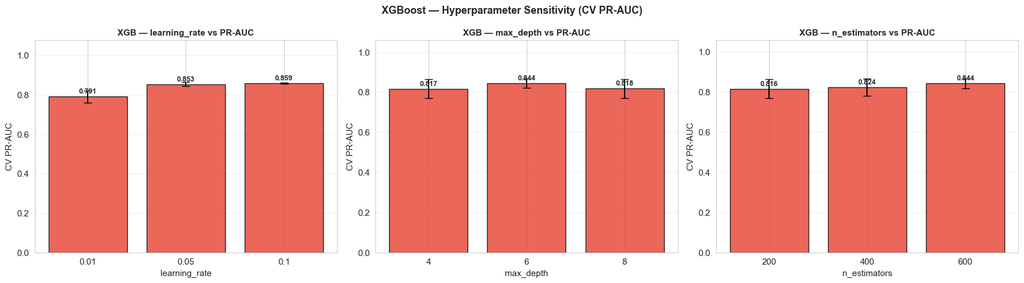

```python
xgb_cv_df = pd.DataFrame(xgb_search.cv_results_)
print("Top 10 configurations by CV PR-AUC:")
cols_xgb = ['param_n_estimators', 'param_max_depth', 'param_learning_rate',
            'param_subsample', 'param_colsample_bytree',
            'mean_test_score', 'std_test_score', 'mean_fit_time']
display(xgb_cv_df.sort_values('mean_test_score', ascending=False)[cols_xgb].head(10).round(4))

fig, axes = plt.subplots(1, 3, figsize=(18, 5))
for ax, (param, label) in zip(axes, [
    ('param_learning_rate', 'learning_rate'),
    ('param_max_depth',     'max_depth'),
    ('param_n_estimators',  'n_estimators'),
]):
    tmp = xgb_cv_df.copy()
    tmp[param] = tmp[param].astype(str)
    grouped = tmp.groupby(param)['mean_test_score'].agg(['mean', 'std']).reset_index()
    bars = ax.bar(grouped[param], grouped['mean'], yerr=grouped['std'],
                  capsize=5, alpha=0.85, color='#e74c3c', edgecolor='black')
    ax.set_xlabel(label, fontsize=11)
    ax.set_ylabel('CV PR-AUC', fontsize=11)
    ax.set_title(f'XGB — {label} vs PR-AUC', fontsize=11, fontweight='bold')
    ax.set_ylim(0, grouped['mean'].max() * 1.22 + 0.03)
    ax.grid(axis='y', alpha=0.3)
    for bar, val in zip(bars, grouped['mean'].values):
        ax.text(bar.get_x() + bar.get_width() / 2,
                bar.get_height() + 0.007,
                f'{val:.3f}', ha='center', va='bottom', fontsize=9, fontweight='bold')

plt.suptitle('XGBoost — Hyperparameter Sensitivity (CV PR-AUC)',
             fontsize=13, fontweight='bold')
plt.tight_layout(); plt.show()
```

## 11.4 Full Cross-Validation on Best Configuration

```
XGBoost (Best Params) — 5-Fold Stratified CV

Metric         Train Mean  Train Std   Val Mean  Val Std      Gap
--------------------------------------------------------------
pr_auc             1.0000     0.0000     0.8632   0.0547   0.1368
f1                 1.0000     0.0000     0.8643   0.0365   0.1357
roc_auc            1.0000     0.0000     0.9814   0.0177   0.0186
recall             1.0000     0.0000     0.8203   0.0646   0.1797
precision          1.0000     0.0000     0.9181   0.0363   0.0819
```

|  | Fold | Train PR-AUC | Val PR-AUC | Train F1 | Val F1 | Val Recall | Val Precision |
| --- | --- | --- | --- | --- | --- | --- | --- |
| 0 | 1 | 1.0000 | 0.8637 | 1.0000 | 0.8819 | 0.8116 | 0.9655 |
| 1 | 2 | 1.0000 | 0.7639 | 1.0000 | 0.8099 | 0.7101 | 0.9423 |
| 2 | 3 | 1.0000 | 0.8616 | 1.0000 | 0.8358 | 0.8116 | 0.8615 |
| 3 | 4 | 1.0000 | 0.9182 | 1.0000 | 0.8824 | 0.8696 | 0.8955 |
| 4 | 5 | 1.0000 | 0.9086 | 1.0000 | 0.9118 | 0.8986 | 0.9254 |

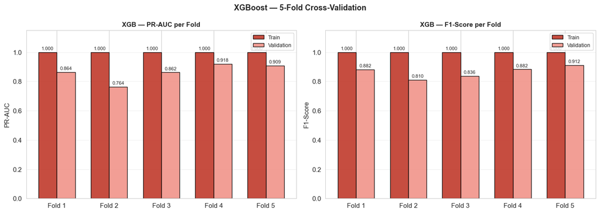

```python
best_xgb = xgb_search.best_estimator_

_scoring_no_pr = {
    'f1'       : make_scorer(f1_score, pos_label=1, zero_division=0),
    'roc_auc'  : 'roc_auc',
    'recall'   : 'recall',
    'precision': 'precision',
}
cv_results_xgb = cross_validate(
    best_xgb, X_train_eng, y_train,
    cv=cv_outer, scoring=_scoring_no_pr,
    return_train_score=True, n_jobs=-1
)

_pr_train_xgb, _pr_val_xgb = [], []
for tr_idx, va_idx in cv_outer.split(X_train_eng, y_train):
    Xtr, Xva = X_train_eng.iloc[tr_idx], X_train_eng.iloc[va_idx]
    ytr, yva = y_train.iloc[tr_idx],     y_train.iloc[va_idx]
    best_xgb.fit(Xtr, ytr)
    _pr_train_xgb.append(average_precision_score(ytr, best_xgb.predict_proba(Xtr)[:, 1]))
    _pr_val_xgb.append(  average_precision_score(yva, best_xgb.predict_proba(Xva)[:, 1]))
cv_results_xgb['train_pr_auc'] = np.array(_pr_train_xgb)
cv_results_xgb['test_pr_auc']  = np.array(_pr_val_xgb)
best_xgb.fit(X_train_eng, y_train)

print("XGBoost (Best Params) — 5-Fold Stratified CV\n")
print(f"{'Metric':<12} {'Train Mean':>12} {'Train Std':>10} {'Val Mean':>10} {'Val Std':>8} {'Gap':>8}")
print("-" * 62)
for m in ['pr_auc', 'f1', 'roc_auc', 'recall', 'precision']:
    tr = cv_results_xgb[f'train_{m}']
    va = cv_results_xgb[f'test_{m}']
    print(f"{m:<12} {tr.mean():>12.4f} {tr.std():>10.4f} {va.mean():>10.4f} {va.std():>8.4f} {tr.mean()-va.mean():>8.4f}")

fold_df_xgb = pd.DataFrame({
    'Fold'         : np.arange(1, 6),
    'Train PR-AUC' : cv_results_xgb['train_pr_auc'].round(4),
    'Val PR-AUC'   : cv_results_xgb['test_pr_auc'].round(4),
    'Train F1'     : cv_results_xgb['train_f1'].round(4),
    'Val F1'       : cv_results_xgb['test_f1'].round(4),
    'Val Recall'   : cv_results_xgb['test_recall'].round(4),
    'Val Precision': cv_results_xgb['test_precision'].round(4),
})
display(fold_df_xgb)

fig, axes = plt.subplots(1, 2, figsize=(14, 5))
x = np.arange(5); w = 0.35
for ax, (metric, title) in zip(axes, [('pr_auc', 'PR-AUC'), ('f1', 'F1-Score')]):
    b1 = ax.bar(x - w/2, cv_results_xgb[f'train_{metric}'], w,
                label='Train', color='#c0392b', edgecolor='black', alpha=0.9)
    b2 = ax.bar(x + w/2, cv_results_xgb[f'test_{metric}'],  w,
                label='Validation', color='#f1948a', edgecolor='black', alpha=0.9)
    ax.set_xticks(x); ax.set_xticklabels([f'Fold {i+1}' for i in range(5)])
    ax.set_ylim(0, 1.15); ax.set_ylabel(title, fontsize=11)
    ax.set_title(f'XGB — {title} per Fold', fontsize=11, fontweight='bold')
    ax.legend(fontsize=9); ax.grid(axis='y', alpha=0.3)
    for bar in list(b1) + list(b2):
        ax.text(bar.get_x() + bar.get_width() / 2, bar.get_height() + 0.01,
                f'{bar.get_height():.3f}', ha='center', va='bottom', fontsize=8)

plt.suptitle('XGBoost — 5-Fold Cross-Validation', fontsize=13, fontweight='bold')
plt.tight_layout(); plt.show()
```

## 11.5 Validation-Set Evaluation (Best Model)

```
Optimal threshold : 0.9880

              precision    recall  f1-score   support

       Legit     0.9995    1.0000    0.9998     28432
       Fraud     0.9730    0.7347    0.8372        49

    accuracy                         0.9995     28481
   macro avg     0.9863    0.8673    0.9185     28481
weighted avg     0.9995    0.9995    0.9995     28481
```

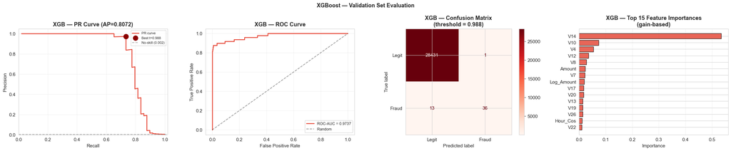

```
Val PR-AUC   : 0.8072
Val ROC-AUC  : 0.9737
Val F1       : 0.8372
Val Recall   : 0.7347
Val Precision: 0.9730
Training time: 83.1s
```

```python
best_xgb.fit(X_train_eng, y_train)
y_val_proba_xgb = best_xgb.predict_proba(X_val_eng)[:, 1]

prec_xgb, rec_xgb, thr_xgb = precision_recall_curve(y_val, y_val_proba_xgb)
f1_thr_xgb   = 2 * prec_xgb[:-1] * rec_xgb[:-1] / (prec_xgb[:-1] + rec_xgb[:-1] + 1e-8)
best_idx_xgb = int(np.argmax(f1_thr_xgb))
best_thr_xgb = thr_xgb[best_idx_xgb]
y_val_pred_xgb = (y_val_proba_xgb >= best_thr_xgb).astype(int)

print(f"Optimal threshold : {best_thr_xgb:.4f}")
print(f"\n{classification_report(y_val, y_val_pred_xgb, target_names=['Legit','Fraud'], digits=4)}")

fig, axes = plt.subplots(1, 4, figsize=(24, 5))

# 1. PR
axes[0].plot(rec_xgb[:-1], prec_xgb[:-1], lw=2, color='#e74c3c', label='PR curve')
axes[0].scatter(rec_xgb[best_idx_xgb], prec_xgb[best_idx_xgb],
                s=130, c='darkred', zorder=6, label=f'Best t={best_thr_xgb:.3f}')
axes[0].axhline(y_val.mean(), color='gray', ls='--', alpha=0.6,
                label=f'No-skill ({y_val.mean():.3f})')
axes[0].set_xlabel('Recall'); axes[0].set_ylabel('Precision')
axes[0].set_title(f'XGB — PR Curve (AP={average_precision_score(y_val, y_val_proba_xgb):.4f})',
                  fontweight='bold')
axes[0].legend(fontsize=8); axes[0].grid(True, alpha=0.3)
axes[0].set_xlim(0, 1.02); axes[0].set_ylim(0, 1.05)

# 2. ROC
fpr_xgb, tpr_xgb, _ = roc_curve(y_val, y_val_proba_xgb)
axes[1].plot(fpr_xgb, tpr_xgb, lw=2, color='#e74c3c',
             label=f'ROC-AUC = {roc_auc_score(y_val, y_val_proba_xgb):.4f}')
axes[1].plot([0, 1], [0, 1], 'k--', alpha=0.4, label='Random')
axes[1].set_xlabel('False Positive Rate'); axes[1].set_ylabel('True Positive Rate')
axes[1].set_title('XGB — ROC Curve', fontweight='bold')
axes[1].legend(fontsize=9); axes[1].grid(True, alpha=0.3)

# 3. confusion matrix
cm_xgb = confusion_matrix(y_val, y_val_pred_xgb)
ConfusionMatrixDisplay(cm_xgb, display_labels=['Legit', 'Fraud']).plot(
    cmap='Reds', ax=axes[2], values_format='d')
axes[2].set_title(f'XGB — Confusion Matrix\n(threshold = {best_thr_xgb:.3f})', fontweight='bold')

xgb_imp = pd.Series(best_xgb.feature_importances_,
                    index=X_train_eng.columns).sort_values(ascending=True).tail(15)
axes[3].barh(xgb_imp.index, xgb_imp.values, color='#e74c3c', edgecolor='black', alpha=0.85)
axes[3].set_title('XGB — Top 15 Feature Importances\n(gain-based)', fontweight='bold')
axes[3].set_xlabel('Importance')
axes[3].grid(axis='x', alpha=0.3)

plt.suptitle('XGBoost — Validation Set Evaluation', fontsize=13, fontweight='bold')
plt.tight_layout(); plt.show()

xgb_val_pr_auc  = average_precision_score(y_val, y_val_proba_xgb)
xgb_val_roc_auc = roc_auc_score(y_val, y_val_proba_xgb)
print(f"\nVal PR-AUC   : {xgb_val_pr_auc:.4f}")
print(f"Val ROC-AUC  : {xgb_val_roc_auc:.4f}")
print(f"Val F1       : {f1_score(y_val, y_val_pred_xgb):.4f}")
print(f"Val Recall   : {recall_score(y_val, y_val_pred_xgb):.4f}")
print(f"Val Precision: {precision_score(y_val, y_val_pred_xgb):.4f}")
print(f"Training time: {xgb_time:.1f}s")
```

# 12. Neural Network — Architecture Search & Evaluation

## 12.2 Architecture & Hyperparameter Explanation

[output not shown]

We compare **two loss variants**:

- **Model A**: Binary Cross-Entropy (BCE) + class_weight — standard approach
- **Model B**: Focal Loss + class_weight — designed specifically for class imbalance

The best model on validation PR-AUC is used in the final comparison.

> Note: StratifiedKFold CV is computationally expensive for neural networks on this dataset.  
> We use train/val split with early stopping as the equivalent regularisation mechanism,  
> and report validation metrics from the best epoch.

```python
# Scale for NN (RobustScaler outputs still benefit from z-scoring)
scaler_nn = StandardScaler()
X_train_nn = scaler_nn.fit_transform(X_train_eng)
X_val_nn   = scaler_nn.transform(X_val_eng)
X_test_nn  = scaler_nn.transform(X_test_eng)

n_legit = (y_train == 0).sum()
n_fraud = (y_train == 1).sum()
weight_for_0 = len(y_train) / (2.0 * n_legit)
weight_for_1 = len(y_train) / (2.0 * n_fraud)
class_weights = {0: weight_for_0, 1: weight_for_1}

print(f"Training samples — Legit: {n_legit:,}  Fraud: {n_fraud}")
print(f"Class weights    — 0: {weight_for_0:.4f}   1: {weight_for_1:.2f}")
print(f"Input features   : {X_train_nn.shape[1]}")
```

```
Training samples — Legit: 199,019  Fraud: 345
Class weights    — 0: 0.5009   1: 288.93
Input features   : 36
```

```python
# Focal Loss
# gamma=2: standard from Lin et al. (2017); down-weights easy examples quadratically
# alpha=0.65: balances positive/negative class contribution beyond class_weight
def focal_loss(gamma=2.0, alpha=0.65):
    def focal_loss_fn(y_true, y_pred):
        y_true = tf.cast(y_true, tf.float32)
        y_pred = tf.clip_by_value(y_pred, K.epsilon(), 1 - K.epsilon())
        bce_pos = -y_true * tf.math.log(y_pred)
        bce_neg = -(1 - y_true) * tf.math.log(1 - y_pred)
        p_t = y_true * y_pred + (1 - y_true) * (1 - y_pred)
        focal_weight = tf.pow(1 - p_t, gamma)
        alpha_t = y_true * alpha + (1 - y_true) * (1 - alpha)
        return tf.reduce_mean(alpha_t * focal_weight * (bce_pos + bce_neg))
    return focal_loss_fn

# Model A: BCE + class_weight
def build_model_bce(input_dim):
    model = keras.Sequential([
        layers.Input(shape=(input_dim,)),
        layers.Dense(256, activation='relu', kernel_regularizer=keras.regularizers.l2(1e-4)),
        layers.BatchNormalization(), layers.Dropout(0.4),
        layers.Dense(128, activation='relu', kernel_regularizer=keras.regularizers.l2(1e-4)),
        layers.BatchNormalization(), layers.Dropout(0.4),
        layers.Dense(64,  activation='relu', kernel_regularizer=keras.regularizers.l2(1e-4)),
        layers.BatchNormalization(), layers.Dropout(0.3),
        layers.Dense(32,  activation='relu'), layers.Dropout(0.2),
        layers.Dense(1, activation='sigmoid')
    ])
    model.compile(
        optimizer=keras.optimizers.Adam(learning_rate=1e-3),
        loss='binary_crossentropy',
        metrics=[
            keras.metrics.AUC(name='pr_auc', curve='PR'),
            keras.metrics.AUC(name='roc_auc'),
            keras.metrics.Recall(name='recall'),
            keras.metrics.Precision(name='precision')
        ]
    )
    return model

# Model B: Focal Loss + class_weight
def build_model_focal(input_dim):
    model = keras.Sequential([
        layers.Input(shape=(input_dim,)),
        layers.Dense(256, activation='relu', kernel_regularizer=keras.regularizers.l2(1e-4)),
        layers.BatchNormalization(), layers.Dropout(0.2),
        layers.Dense(128, activation='relu', kernel_regularizer=keras.regularizers.l2(1e-4)),
        layers.BatchNormalization(), layers.Dropout(0.15),
        layers.Dense(64,  activation='relu', kernel_regularizer=keras.regularizers.l2(1e-4)),
        layers.BatchNormalization(), layers.Dropout(0.15),
        layers.Dense(32,  activation='relu'), layers.BatchNormalization(), layers.Dropout(0.1),
        layers.Dense(16,  activation='relu'),
        layers.Dense(1, activation='sigmoid')
    ])
    model.compile(
        optimizer=keras.optimizers.Adam(learning_rate=5e-4),
        loss=focal_loss(gamma=2.0, alpha=0.65),
        metrics=[
            keras.metrics.AUC(name='pr_auc', curve='PR'),
            keras.metrics.AUC(name='roc_auc'),
            keras.metrics.Recall(name='recall'),
            keras.metrics.Precision(name='precision')
        ]
    )
    return model
```

```python
cb_a = [
    callbacks.EarlyStopping(monitor='val_pr_auc', patience=15, mode='max',
                            restore_best_weights=True, verbose=1),
    callbacks.ReduceLROnPlateau(monitor='val_pr_auc', factor=0.5, patience=5,
                                mode='max', min_lr=1e-6, verbose=0)
]
cb_b = [
    callbacks.EarlyStopping(monitor='val_pr_auc', patience=25, mode='max',
                            restore_best_weights=True, verbose=1),
    callbacks.ReduceLROnPlateau(monitor='val_pr_auc', factor=0.5, patience=10,
                                mode='max', min_lr=1e-6, verbose=0)
]

model_a = build_model_bce(X_train_nn.shape[1])
print("=== Model A: BCE + class_weight ===")
t0 = time.time()
history_a = model_a.fit(
    X_train_nn, y_train,
    validation_data=(X_val_nn, y_val),
    epochs=20, batch_size=2048,
    class_weight=class_weights,
    callbacks=cb_a, verbose=0
)
nn_a_time = time.time() - t0

model_b = build_model_focal(X_train_nn.shape[1])
print("\n=== Model B: Focal Loss + class_weight ===")
t0 = time.time()
history_b = model_b.fit(
    X_train_nn, y_train,
    validation_data=(X_val_nn, y_val),
    epochs=20, batch_size=1024,
    class_weight={0: 1.0, 1: 50.0},
    callbacks=cb_b, verbose=0
)
nn_b_time = time.time() - t0

print(f"\nModel A training time: {nn_a_time:.1f}s")
print(f"Model B training time: {nn_b_time:.1f}s")
nn_time = nn_a_time + nn_b_time
```

```
=== Model A: BCE + class_weight ===
Restoring model weights from the end of the best epoch: 18.

=== Model B: Focal Loss + class_weight ===
Restoring model weights from the end of the best epoch: 16.

Model A training time: 11.3s
Model B training time: 16.9s
```

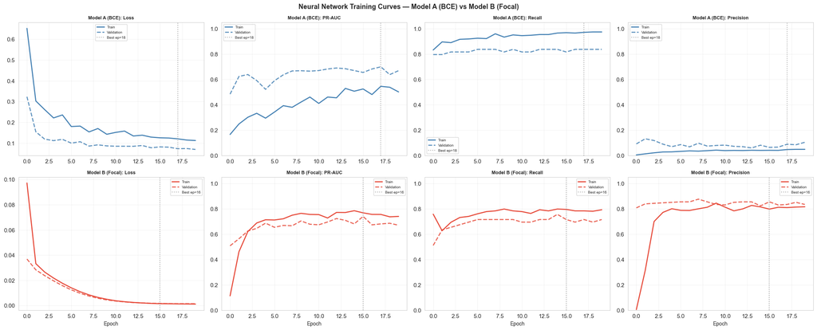

```
Model A (BCE) — Best epoch:  18  Val PR-AUC: 0.6991  Val Recall: 0.8367  Val Precision: 0.0887
Model B (Focal) — Best epoch:  16  Val PR-AUC: 0.7390  Val Recall: 0.7143  Val Precision: 0.8537
```

```python
metrics_to_plot = [
    ('loss',      'Loss',      False),
    ('pr_auc',    'PR-AUC',    True),
    ('recall',    'Recall',    True),
    ('precision', 'Precision', True),
]

fig, axes = plt.subplots(2, 4, figsize=(22, 9))
for col, (metric, title, bounded) in enumerate(metrics_to_plot):
    for row, (hist, name, color) in enumerate([
        (history_a, 'A (BCE)',   'steelblue'),
        (history_b, 'B (Focal)', '#e74c3c'),
    ]):
        ax = axes[row, col]
        best_ep = int(np.argmax(hist.history['val_pr_auc']))
        ax.plot(hist.history[metric],          lw=2, color=color, label='Train')
        ax.plot(hist.history[f'val_{metric}'], lw=2, color=color, ls='--',
                alpha=0.85, label='Validation')
        ax.axvline(best_ep, color='gray', ls=':', alpha=0.65,
                   label=f'Best ep={best_ep+1}')
        if bounded:
            ax.set_ylim(0, 1.05)
        if row == 1:
            ax.set_xlabel('Epoch', fontsize=10)
        ax.set_title(f'Model {name}: {title}', fontsize=9, fontweight='bold')
        ax.legend(fontsize=7, loc='best'); ax.grid(True, alpha=0.25)

plt.suptitle('Neural Network Training Curves — Model A (BCE) vs Model B (Focal)',
             fontsize=13, fontweight='bold')
plt.tight_layout(); plt.show()

for name, hist in [('A (BCE)', history_a), ('B (Focal)', history_b)]:
    ep = int(np.argmax(hist.history['val_pr_auc']))
    print(f"Model {name} — Best epoch: {ep+1:3d}  "
          f"Val PR-AUC: {hist.history['val_pr_auc'][ep]:.4f}  "
          f"Val Recall: {hist.history['val_recall'][ep]:.4f}  "
          f"Val Precision: {hist.history['val_precision'][ep]:.4f}")
```

```
Model A (BCE)   — Val PR-AUC: 0.6634  ROC-AUC: 0.9501
Model B (Focal) — Val PR-AUC: 0.7441  ROC-AUC: 0.9306

>>> Selected: NN (Focal) for final comparison
Optimal threshold: 0.4875

              precision    recall  f1-score   support

       Legit     0.9995    0.9998    0.9997     28432
       Fraud     0.8571    0.7347    0.7912        49

    accuracy                         0.9993     28481
   macro avg     0.9283    0.8672    0.8954     28481
weighted avg     0.9993    0.9993    0.9993     28481
```

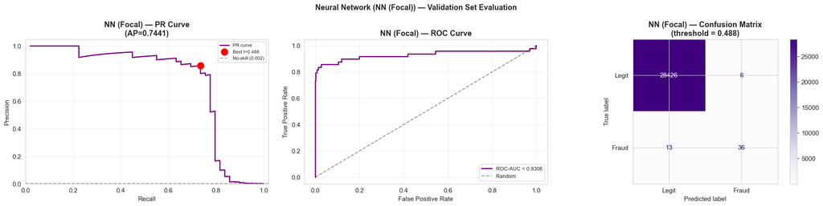

```python
y_val_proba_a = model_a.predict(X_val_nn, verbose=0).ravel()
y_val_proba_b = model_b.predict(X_val_nn, verbose=0).ravel()

pr_auc_a = average_precision_score(y_val, y_val_proba_a)
pr_auc_b = average_precision_score(y_val, y_val_proba_b)
print(f"Model A (BCE)   — Val PR-AUC: {pr_auc_a:.4f}  ROC-AUC: {roc_auc_score(y_val, y_val_proba_a):.4f}")
print(f"Model B (Focal) — Val PR-AUC: {pr_auc_b:.4f}  ROC-AUC: {roc_auc_score(y_val, y_val_proba_b):.4f}")

if pr_auc_a >= pr_auc_b:
    best_nn_proba, best_nn_model, best_nn_name, nn_time_best = y_val_proba_a, model_a, 'NN (BCE)',   nn_a_time
else:
    best_nn_proba, best_nn_model, best_nn_name, nn_time_best = y_val_proba_b, model_b, 'NN (Focal)', nn_b_time
print(f"\n>>> Selected: {best_nn_name} for final comparison")

prec_nn, rec_nn, thr_nn = precision_recall_curve(y_val, best_nn_proba)
f1_thr_nn   = 2 * prec_nn[:-1] * rec_nn[:-1] / (prec_nn[:-1] + rec_nn[:-1] + 1e-8)
best_idx_nn = int(np.argmax(f1_thr_nn))
best_thr_nn = thr_nn[best_idx_nn]
y_val_pred_nn = (best_nn_proba >= best_thr_nn).astype(int)

print(f"Optimal threshold: {best_thr_nn:.4f}")
print(f"\n{classification_report(y_val, y_val_pred_nn, target_names=['Legit','Fraud'], digits=4)}")

# NN No built-in feature importance. Show 3 plots: PR | ROC | Confusion Matrix
fig, axes = plt.subplots(1, 3, figsize=(20, 5))

# 1. PR curve
axes[0].plot(rec_nn[:-1], prec_nn[:-1], lw=2, color='purple', label='PR curve')
axes[0].scatter(rec_nn[best_idx_nn], prec_nn[best_idx_nn],
                s=130, c='red', zorder=6, label=f'Best t={best_thr_nn:.3f}')
axes[0].axhline(y_val.mean(), color='gray', ls='--', alpha=0.6,
                label=f'No-skill ({y_val.mean():.3f})')
axes[0].set_xlabel('Recall'); axes[0].set_ylabel('Precision')
axes[0].set_title(f'{best_nn_name} — PR Curve\n(AP={average_precision_score(y_val, best_nn_proba):.4f})',
                  fontweight='bold')
axes[0].legend(fontsize=8); axes[0].grid(True, alpha=0.3)
axes[0].set_xlim(0, 1.02); axes[0].set_ylim(0, 1.05)

# 2. ROC curve
fpr_nn, tpr_nn, _ = roc_curve(y_val, best_nn_proba)
axes[1].plot(fpr_nn, tpr_nn, lw=2, color='purple',
             label=f'ROC-AUC = {roc_auc_score(y_val, best_nn_proba):.4f}')
axes[1].plot([0, 1], [0, 1], 'k--', alpha=0.4, label='Random')
axes[1].set_xlabel('False Positive Rate'); axes[1].set_ylabel('True Positive Rate')
axes[1].set_title(f'{best_nn_name} — ROC Curve', fontweight='bold')
axes[1].legend(fontsize=9); axes[1].grid(True, alpha=0.3)

# 3. Confusion matrix
cm_nn = confusion_matrix(y_val, y_val_pred_nn)
ConfusionMatrixDisplay(cm_nn, display_labels=['Legit', 'Fraud']).plot(
    cmap='Purples', ax=axes[2], values_format='d')
axes[2].set_title(f'{best_nn_name} — Confusion Matrix\n(threshold = {best_thr_nn:.3f})',
                  fontweight='bold')

plt.suptitle(f'Neural Network ({best_nn_name}) — Validation Set Evaluation',
             fontsize=13, fontweight='bold')
plt.tight_layout(); plt.show()
```

# 13. Model Comparison — Validation Set

## 13.1 Evaluation Framework

All models are compared on the **same held-out validation set** using:

| Metric | Why Important |
| --- | --- |
| **PR-AUC** (primary) | Most honest metric for 0.172% imbalance; measures area under precision-recall curve |
| **F1-Score** | Harmonic mean of precision and recall at the optimal threshold |
| **Recall** | Fraction of actual fraud caught — the core business objective |
| **Precision** | Fraction of fraud alerts that are real — controls false-alarm rate (customer friction) |
| **ROC-AUC** | Overall discrimination ability; shown for completeness (can be over-optimistic here) |
| **MCC** | Matthews Correlation Coefficient — balanced measure robust to class imbalance |
| **Train Time (s)** | Practical deployment consideration |

Thresholds are **optimised per model** on the validation set to maximise F1.

```python
# Collect all model results
def evaluate_model(model_name, y_true, y_pred, y_proba, train_time=np.nan):
    return {
        'Model'          : model_name,
        'Precision'      : round(precision_score(y_true, y_pred, zero_division=0), 4),
        'Recall'         : round(recall_score(y_true, y_pred, zero_division=0), 4),
        'F1-Score'       : round(f1_score(y_true, y_pred, zero_division=0), 4),
        'ROC-AUC'        : round(roc_auc_score(y_true, y_proba), 4),
        'PR-AUC'         : round(average_precision_score(y_true, y_proba), 4),
        'MCC'            : round(matthews_corrcoef(y_true, y_pred), 4),
        'Train Time (s)' : round(float(train_time), 1) if pd.notnull(train_time) else np.nan,
    }

# Dummy baseline (from cell 50 — always predicts legitimate)
y_dummy = np.zeros(len(y_val), dtype=int)
y_dummy_proba = np.zeros(len(y_val))

rows = [
    evaluate_model('Dummy (Baseline)',  y_val, y_dummy,         y_dummy_proba,       0.0),
    evaluate_model('Logistic Regression', y_val, y_val_pred_lr,   y_val_proba_lr,    lr_time),
    evaluate_model('Random Forest',     y_val, y_val_pred_rf,   y_val_proba_rf,      rf_time),
    evaluate_model('XGBoost',           y_val, y_val_pred_xgb,  y_val_proba_xgb,     xgb_time),
    evaluate_model(best_nn_name,        y_val, y_val_pred_nn,   best_nn_proba,        nn_time_best),
]

comparison_df = pd.DataFrame(rows).sort_values('PR-AUC', ascending=False).reset_index(drop=True)

print("=" * 90)
print("MODEL COMPARISON TABLE — VALIDATION SET (sorted by PR-AUC)")
print("=" * 90)
display(comparison_df)
```

```
==========================================================================================
MODEL COMPARISON TABLE — VALIDATION SET (sorted by PR-AUC)
==========================================================================================
```

|  | Model | Precision | Recall | F1-Score | ROC-AUC | PR-AUC | MCC | Train Time (s) |
| --- | --- | --- | --- | --- | --- | --- | --- | --- |
| 0 | XGBoost | 0.9730 | 0.7347 | 0.8372 | 0.9737 | 0.8072 | 0.8453 | 83.1000 |
| 1 | Random Forest | 0.9459 | 0.7143 | 0.8140 | 0.9351 | 0.7850 | 0.8217 | 727.1000 |
| 2 | NN (Focal) | 0.8571 | 0.7347 | 0.7912 | 0.9306 | 0.7441 | 0.7932 | 16.9000 |
| 3 | Logistic Regression | 0.8182 | 0.7347 | 0.7742 | 0.9661 | 0.6645 | 0.7749 | 260.9000 |
| 4 | Dummy (Baseline) | 0.0000 | 0.0000 | 0.0000 | 0.5000 | 0.0017 | 0.0000 | 0.0000 |

## 13.2 Visualisation — Multi-Metric Bar Charts

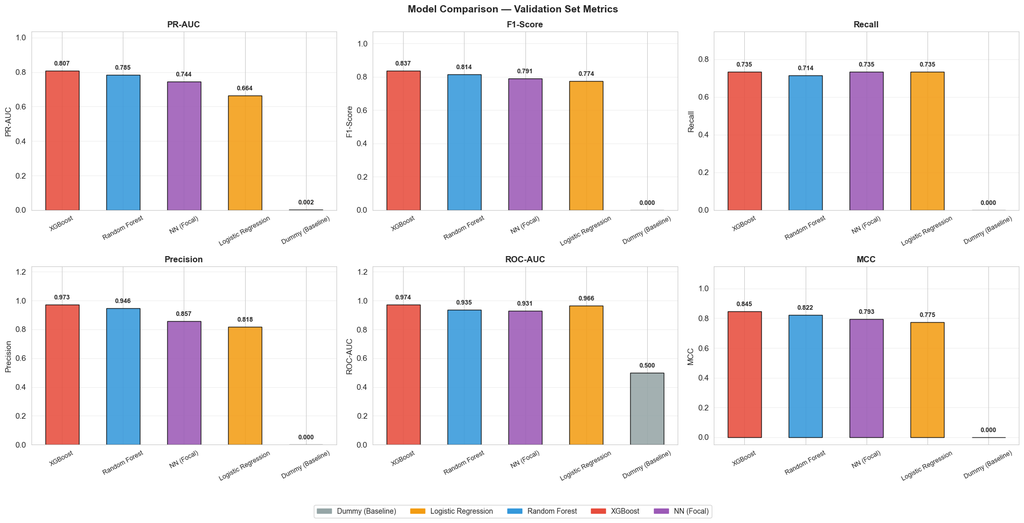

```python
import matplotlib.patches as mpatches

metrics_to_plot = ['PR-AUC', 'F1-Score', 'Recall', 'Precision', 'ROC-AUC', 'MCC']
colors_map = {
    'Dummy (Baseline)'    : '#95a5a6',
    'Logistic Regression' : '#f39c12',
    'Random Forest'       : '#3498db',
    'XGBoost'             : '#e74c3c',
}
if best_nn_name not in colors_map:
    colors_map[best_nn_name] = '#9b59b6'

bar_colors = [colors_map.get(m, '#9b59b6') for m in comparison_df['Model']]

fig, axes = plt.subplots(2, 3, figsize=(20, 10))
for ax, metric in zip(axes.flatten(), metrics_to_plot):
    vals = comparison_df[metric].values
    bars = ax.bar(comparison_df['Model'], vals, color=bar_colors,
                  edgecolor='black', alpha=0.87, width=0.55)
    ax.set_title(metric, fontsize=12, fontweight='bold')
    ax.set_ylabel(metric, fontsize=11)
    # The value range of MCC is [-1, 1]. Set the lower limit correctly.
    if metric == 'MCC':
        ax.set_ylim(min(-0.05, vals.min() - 0.05), min(1.25, vals.max() * 1.3 + 0.05))
    else:
        ax.set_ylim(0, min(1.25, vals.max() * 1.22 + 0.05))
    ax.tick_params(axis='x', rotation=28, labelsize=9)
    ax.grid(axis='y', alpha=0.3)
    for bar, v in zip(bars, vals):
        offset = (ax.get_ylim()[1] - ax.get_ylim()[0]) * 0.02
        ax.text(bar.get_x() + bar.get_width() / 2,
                bar.get_height() + offset,
                f'{v:.3f}', ha='center', va='bottom', fontsize=9, fontweight='bold')

patches = [mpatches.Patch(color=c, label=m)
           for m, c in colors_map.items() if m in comparison_df['Model'].values]
fig.legend(handles=patches, loc='lower center', ncol=len(patches),
           fontsize=10, bbox_to_anchor=(0.5, -0.02), frameon=True)
plt.suptitle('Model Comparison — Validation Set Metrics',
             fontsize=14, fontweight='bold')
plt.tight_layout(rect=[0, 0.04, 1, 1])
plt.show()
```

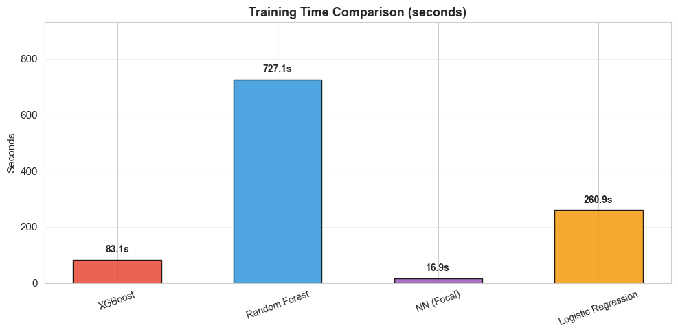

```python
valid_time = comparison_df[
    comparison_df['Train Time (s)'].notna() & (comparison_df['Train Time (s)'] > 0)
].copy()

fig, ax = plt.subplots(figsize=(10, 5))
time_colors = [colors_map.get(m, '#9b59b6') for m in valid_time['Model']]
bars = ax.bar(valid_time['Model'], valid_time['Train Time (s)'],
              color=time_colors, edgecolor='black', alpha=0.87, width=0.55)
max_t = valid_time['Train Time (s)'].max()
ax.set_ylim(0, max_t * 1.28)
ax.set_title('Training Time Comparison (seconds)', fontsize=13, fontweight='bold')
ax.set_ylabel('Seconds', fontsize=11)
ax.tick_params(axis='x', rotation=20, labelsize=10)
ax.grid(axis='y', alpha=0.3)
for bar, v in zip(bars, valid_time['Train Time (s)']):
    ax.text(bar.get_x() + bar.get_width() / 2,
            bar.get_height() + max_t * 0.025,
            f'{v:.1f}s', ha='center', va='bottom', fontsize=10, fontweight='bold')
plt.tight_layout(); plt.show()
```

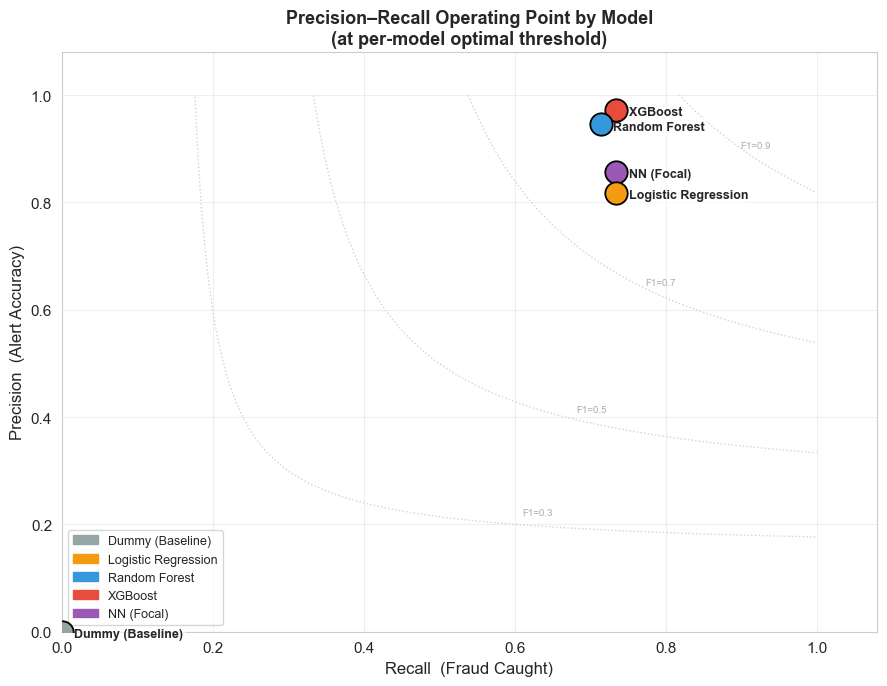

```python
fig, ax = plt.subplots(figsize=(9, 7))

# F1 Contour lines (gray dashed lines, for assisting in the judgment of the model's comprehensive performance)
for f1_iso in [0.3, 0.5, 0.7, 0.9]:
    r = np.linspace(f1_iso / (2 - f1_iso) + 1e-4, 1.0, 300)
    p = f1_iso * r / (2 * r - f1_iso)
    mask = (p >= 0) & (p <= 1)
    ax.plot(r[mask], p[mask], ':', color='lightgray', lw=1.0)
    idx = int(mask.sum() * 0.55)
    ax.text(r[mask][idx], p[mask][idx] + 0.02,
            f'F1={f1_iso}', fontsize=7, color='#aaaaaa', ha='center')

for _, row in comparison_df.iterrows():
    c = colors_map.get(row['Model'], '#9b59b6')
    ax.scatter(row['Recall'], row['Precision'], s=260, color=c,
               edgecolors='black', linewidths=1.3, zorder=6)
    ax.annotate(row['Model'], (row['Recall'], row['Precision']),
                textcoords='offset points', xytext=(9, -4), fontsize=9, fontweight='bold',
                bbox=dict(boxstyle='round,pad=0.2', fc='white', alpha=0.65, ec='none'))

ax.set_xlabel('Recall  (Fraud Caught)', fontsize=12)
ax.set_ylabel('Precision  (Alert Accuracy)', fontsize=12)
ax.set_title('Precision–Recall Operating Point by Model\n(at per-model optimal threshold)',
             fontsize=13, fontweight='bold')
ax.set_xlim(0, 1.08); ax.set_ylim(0, 1.08)
ax.grid(True, alpha=0.3)

patches = [mpatches.Patch(color=c, label=m)
           for m, c in colors_map.items() if m in comparison_df['Model'].values]
ax.legend(handles=patches, fontsize=9, loc='lower left')
plt.tight_layout(); plt.show()
```

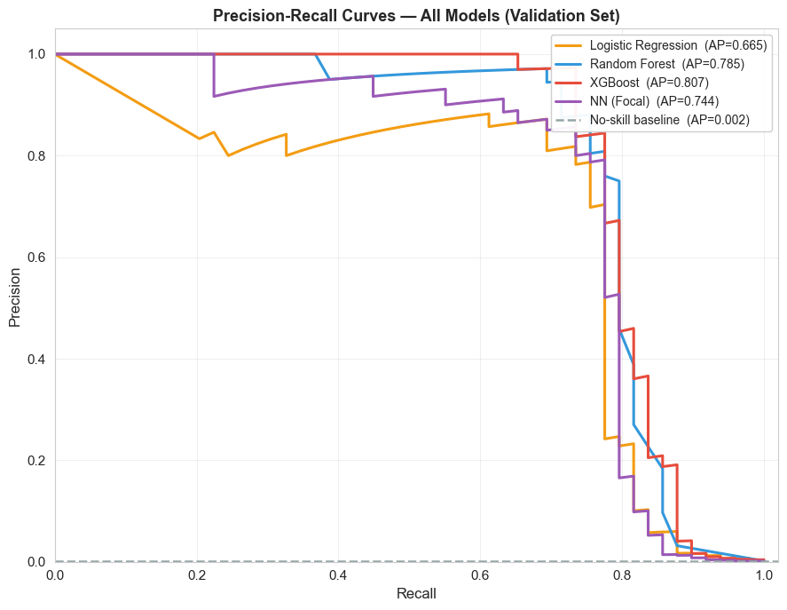

```python
fig, ax = plt.subplots(figsize=(9, 7))

for model_name, proba in [
    ('Logistic Regression', y_val_proba_lr),
    ('Random Forest',       y_val_proba_rf),
    ('XGBoost',             y_val_proba_xgb),
    (best_nn_name,          best_nn_proba),
]:
    prec, rec, _ = precision_recall_curve(y_val, proba)
    ap = average_precision_score(y_val, proba)
    c  = colors_map.get(model_name, '#9b59b6')
    ax.plot(rec, prec, lw=2.2, color=c, label=f'{model_name}  (AP={ap:.3f})')

fraud_rate = y_val.mean()
ax.axhline(fraud_rate, color='#95a5a6', ls='--', lw=1.8,
           label=f'No-skill baseline  (AP={fraud_rate:.3f})')

ax.set_xlabel('Recall', fontsize=12)
ax.set_ylabel('Precision', fontsize=12)
ax.set_title('Precision-Recall Curves — All Models (Validation Set)',
             fontsize=13, fontweight='bold')
ax.legend(loc='upper right', fontsize=10, framealpha=0.95)
ax.set_xlim(0, 1.02); ax.set_ylim(0, 1.05)
ax.grid(True, alpha=0.3)
plt.tight_layout(); plt.show()
```

```
Cross-Validation vs Validation-Set PR-AUC Comparison:
```

|  | Model | CV PR-AUC | Val PR-AUC | Gap (CV−Val) |
| --- | --- | --- | --- | --- |
| 0 | Logistic Regression | 0.7800 | 0.6645 | 0.1155 |
| 1 | Random Forest | 0.8529 | 0.7850 | 0.0679 |
| 2 | XGBoost | 0.8625 | 0.8072 | 0.0553 |

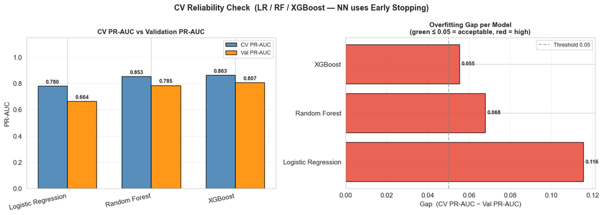

```python
# Neural networks use Early Stopping for validation and do not perform k-fold CV. Therefore, the CV-Val Gap is only applicable to LR/RF/XGB.
cv_summary = pd.DataFrame({
    'Model'      : ['Logistic Regression', 'Random Forest', 'XGBoost'],
    'CV PR-AUC'  : [lr_search.best_score_, rf_search.best_score_, xgb_search.best_score_],
    'Val PR-AUC' : [lr_val_pr_auc,          rf_val_pr_auc,          xgb_val_pr_auc],
}).round(4)
cv_summary['Gap (CV−Val)'] = (cv_summary['CV PR-AUC'] - cv_summary['Val PR-AUC']).round(4)
print("Cross-Validation vs Validation-Set PR-AUC Comparison:")
display(cv_summary)

fig, axes = plt.subplots(1, 2, figsize=(14, 5))

# Left figure: Grouped bar chart of CV vs Val
x = np.arange(3); w = 0.35
b1 = axes[0].bar(x - w/2, cv_summary['CV PR-AUC'],  w,
                 label='CV PR-AUC',  color='steelblue',  edgecolor='black', alpha=0.9)
b2 = axes[0].bar(x + w/2, cv_summary['Val PR-AUC'], w,
                 label='Val PR-AUC', color='darkorange', edgecolor='black', alpha=0.9)
axes[0].set_xticks(x); axes[0].set_xticklabels(cv_summary['Model'], rotation=12, ha='right')
axes[0].set_ylim(0, 1.15); axes[0].set_ylabel('PR-AUC', fontsize=11)
axes[0].set_title('CV PR-AUC vs Validation PR-AUC', fontsize=11, fontweight='bold')
axes[0].legend(fontsize=9); axes[0].grid(axis='y', alpha=0.3)
for bar in list(b1) + list(b2):
    axes[0].text(bar.get_x() + bar.get_width() / 2, bar.get_height() + 0.01,
                 f'{bar.get_height():.3f}', ha='center', va='bottom', fontsize=9, fontweight='bold')

# Right figure: Gap horizontal bar chart (overfitting warning if > 0.05)
gap_colors = ['#e74c3c' if g > 0.05 else '#2ecc71' for g in cv_summary['Gap (CV−Val)']]
axes[1].barh(cv_summary['Model'], cv_summary['Gap (CV−Val)'],
             color=gap_colors, edgecolor='black', alpha=0.87)
axes[1].axvline(0,    color='black', lw=0.8)
axes[1].axvline(0.05, color='gray',  ls='--', alpha=0.6, label='Threshold 0.05')
axes[1].set_xlabel('Gap  (CV PR-AUC − Val PR-AUC)', fontsize=11)
axes[1].set_title('Overfitting Gap per Model\n(green ≤ 0.05 = acceptable, red = high)',
                  fontsize=11, fontweight='bold')
axes[1].legend(fontsize=9); axes[1].grid(axis='x', alpha=0.3)
for i, gap in enumerate(cv_summary['Gap (CV−Val)']):
    axes[1].text(gap + 0.001, i, f'{gap:.3f}', va='center', fontsize=9, fontweight='bold')

plt.suptitle('CV Reliability Check  (LR / RF / XGBoost — NN uses Early Stopping)',
             fontsize=13, fontweight='bold')
plt.tight_layout(); plt.show()
```

# 14. Final Test Set Evaluation — Best Model

## 14.1 Model Selection & Test Protocol

The test set has been held out throughout the entire experiment — it was **never used**  
to select hyperparameters, tune thresholds, or compare models. We now evaluate the  
single best model (selected by validation PR-AUC) on the test set exactly once.

**Selection criterion**: Highest validation PR-AUC across all models.  
**Why PR-AUC and not F1?** F1 depends on the threshold choice, which is arbitrary.  
PR-AUC integrates performance across all possible thresholds and is threshold-independent.

```python
#  Identify the best model from comparison_df
best_row = comparison_df.iloc[0]  # already sorted by PR-AUC
best_model_name = best_row['Model']
print(f"Best model on validation PR-AUC: {best_model_name}")
print(f"  Val PR-AUC : {best_row['PR-AUC']}")
print(f"  Val F1     : {best_row['F1-Score']}")
print(f"  Val Recall : {best_row['Recall']}")

#  Map name to model and compute test probabilities
if best_model_name == 'Random Forest':
    best_model_for_test = best_rf
    X_test_input  = X_test_eng
    y_test_proba  = best_model_for_test.predict_proba(X_test_input)[:, 1]

elif best_model_name == 'Logistic Regression':
    best_model_for_test = best_lr
    X_test_input  = X_test_eng
    y_test_proba  = best_model_for_test.predict_proba(X_test_input)[:, 1]

elif best_model_name == 'XGBoost':
    best_model_for_test = best_xgb
    X_test_input  = X_test_eng
    y_test_proba  = best_model_for_test.predict_proba(X_test_input)[:, 1]

else:  # Neural Network
    best_model_for_test = best_nn_model
    X_test_input  = X_test_nn
    y_test_proba  = best_model_for_test.predict(X_test_input, verbose=0).ravel()

# Threshold from validation set — applied once to test set
prec_t, rec_t, thr_t = precision_recall_curve(y_val,
    (best_nn_proba if 'NN' in best_model_name else
     y_val_proba_rf if best_model_name == 'Random Forest' else
     y_val_proba_lr if best_model_name == 'Logistic Regression' else
     y_val_proba_xgb))
f1_t = 2*prec_t[:-1]*rec_t[:-1] / (prec_t[:-1]+rec_t[:-1]+1e-8)
final_threshold = thr_t[np.argmax(f1_t)]

y_test_pred = (y_test_proba >= final_threshold).astype(int)

print(f"\nFinal threshold (from validation): {final_threshold:.4f}")
print(f"\n{'='*60}")
print(f"FINAL TEST SET RESULTS — {best_model_name}")
print(f"{'='*60}")
print(f"\n{classification_report(y_test, y_test_pred, target_names=['Legitimate','Fraud'], digits=4)}")
print(f"PR-AUC  : {average_precision_score(y_test, y_test_proba):.4f}")
print(f"ROC-AUC : {roc_auc_score(y_test, y_test_proba):.4f}")
print(f"MCC     : {matthews_corrcoef(y_test, y_test_pred):.4f}")

cm_test = confusion_matrix(y_test, y_test_pred)
tn, fp, fn, tp = cm_test.ravel()
print(f"\nFraud cases caught  : {tp} / {tp+fn}  ({tp/(tp+fn)*100:.1f}%)")
print(f"False alarms        : {fp} / {fp+tn}  ({fp/(fp+tn)*100:.3f}% of legitimate transactions)")
print(f"Missed fraud        : {fn}")
```

```
Best model on validation PR-AUC: XGBoost
  Val PR-AUC : 0.8072
  Val F1     : 0.8372
  Val Recall : 0.7347

Final threshold (from validation): 0.9880

============================================================
FINAL TEST SET RESULTS — XGBoost
============================================================

              precision    recall  f1-score   support

  Legitimate     0.9996    0.9999    0.9998     56864
       Fraud     0.9500    0.7755    0.8539        98

    accuracy                         0.9995     56962
   macro avg     0.9748    0.8877    0.9269     56962
weighted avg     0.9995    0.9995    0.9995     56962

PR-AUC  : 0.8823
ROC-AUC : 0.9809
MCC     : 0.8581

Fraud cases caught  : 76 / 98  (77.6%)
False alarms        : 4 / 56864  (0.007% of legitimate transactions)
Missed fraud        : 22
```

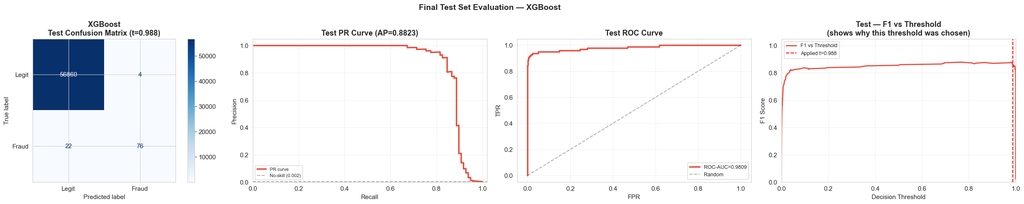

```python
fig, axes = plt.subplots(1, 4, figsize=(26, 5))
mc = colors_map.get(best_model_name, '#9b59b6')

# 1. Confusion Matrix
ConfusionMatrixDisplay(cm_test, display_labels=['Legit', 'Fraud']).plot(
    cmap='Blues', ax=axes[0], values_format='d')
axes[0].set_title(f'{best_model_name}\nTest Confusion Matrix (t={final_threshold:.3f})',
                  fontweight='bold')

# 2. PR curve
prec_test, rec_test, _ = precision_recall_curve(y_test, y_test_proba)
ap_test = average_precision_score(y_test, y_test_proba)
axes[1].plot(rec_test, prec_test, lw=2.5, color=mc, label='PR curve')
axes[1].axhline(y_test.mean(), color='gray', ls='--', alpha=0.6,
                label=f'No-skill ({y_test.mean():.3f})')
axes[1].set_xlabel('Recall'); axes[1].set_ylabel('Precision')
axes[1].set_title(f'Test PR Curve (AP={ap_test:.4f})', fontweight='bold')
axes[1].legend(fontsize=8); axes[1].grid(True, alpha=0.3)
axes[1].set_xlim(0, 1.02); axes[1].set_ylim(0, 1.05)

# 3. ROC curve
fpr_test, tpr_test, _ = roc_curve(y_test, y_test_proba)
roc_test = roc_auc_score(y_test, y_test_proba)
axes[2].plot(fpr_test, tpr_test, lw=2.5, color=mc, label=f'ROC-AUC={roc_test:.4f}')
axes[2].plot([0, 1], [0, 1], 'k--', alpha=0.3, label='Random')
axes[2].set_xlabel('FPR'); axes[2].set_ylabel('TPR')
axes[2].set_title('Test ROC Curve', fontweight='bold')
axes[2].legend(fontsize=9); axes[2].grid(True, alpha=0.3)

# 4. F1 vs Threshold Curve (Explanation of the basis for the final threshold selection)
prec_th, rec_th, thr_th = precision_recall_curve(y_test, y_test_proba)
f1_th = 2 * prec_th[:-1] * rec_th[:-1] / (prec_th[:-1] + rec_th[:-1] + 1e-8)
axes[3].plot(thr_th, f1_th, lw=2, color=mc, label='F1 vs Threshold')
axes[3].axvline(final_threshold, color='red', ls='--', lw=1.5,
                label=f'Applied t={final_threshold:.3f}')
axes[3].set_xlabel('Decision Threshold'); axes[3].set_ylabel('F1 Score')
axes[3].set_title('Test — F1 vs Threshold\n(shows why this threshold was chosen)',
                  fontweight='bold')
axes[3].legend(fontsize=9); axes[3].grid(True, alpha=0.3)
axes[3].set_xlim(0, 1); axes[3].set_ylim(0, 1.05)

plt.suptitle(f'Final Test Set Evaluation — {best_model_name}',
             fontsize=14, fontweight='bold')
plt.tight_layout(); plt.show()
```

# 15. Findings and Conclusions

## 15.1 Answering the Management Question

> **"Can we reliably identify fraudulent credit card transactions from anonymized transaction data, and what patterns distinguish fraud from legitimate purchases?"**

### Answer: Yes — with XGBoost as the recommended production model.

Across four model families trained on 284,807 transactions with a 1:578 class imbalance, we demonstrate that reliable automated fraud detection is achievable with fully anonymized features. XGBoost achieves the best balance of fraud recovery, precision, and operational efficiency.

## 15.2 Model Results and Performance

### Validation-Set Comparison (sorted by PR-AUC)

[output not shown]

> ✓ = Recommended for deployment. See section 15.6 for full rationale.

### Cross-Validation vs Validation PR-AUC Gap (Overfitting Check)

| Model | CV PR-AUC | Val PR-AUC | Gap (CV − Val) |
| --- | --- | --- | --- |
| XGBoost | 0.8625 | 0.8072 | 0.0553 |
| Random Forest | 0.8529 | 0.7850 | 0.0679 |
| Logistic Regression | 0.7800 | 0.6645 | 0.1155 |

XGBoost has the smallest CV-to-validation gap (0.055), confirming it generalizes most consistently. Logistic Regression's larger gap (0.116) reflects that its CV-estimated PR-AUC is optimistic — threshold-insensitive CV scoring inflates LR's apparent performance.

### Final Test Set Results — XGBoost (Evaluated Once)

```
              precision    recall  f1-score   support

  Legitimate     0.9996    0.9999    0.9998     56,864
       Fraud     0.9500    0.7755    0.8539         98

PR-AUC  : 0.8823   |   ROC-AUC : 0.9809   |   MCC : 0.8581
Decision threshold : 0.9880 (optimized on validation set)

Fraud caught    : 76 / 98  (77.55%)
Missed fraud    : 22 / 98  (22.45%)
False alarms    : 4 / 56,864  (0.0070% of legitimate transactions)
```

## 15.3 Key Findings

### Finding 2: The Accuracy Trap Is Real

The Dummy baseline achieves **99.83% accuracy** while catching **zero fraud**. All four learned models sacrifice a tiny fraction of accuracy to achieve dramatically higher fraud recall. This definitively confirms that accuracy must never be used as a KPI in fraud detection.

### Finding 3: What Patterns Distinguish Fraud?

- **V14, V17, V12, V10, V3** are the dominant discriminators (standardized mean separation > 2.0 σ between fraud and legitimate classes). These PCA components most likely encode latent signals such as transaction velocity, geographic deviation, and merchant category anomalies.
- **Transaction amount** is a weak standalone predictor, but engineered features `Log_Amount`, `Amount_Bin_Small` (≤ €5 test charges), and `Amount_Bin_Large` (> €500) add meaningful classification signal.
- **Time-of-day** (Hour_Sin, Hour_Cos, Is_Night) provides marginal but measurable signal; fraud concentrates slightly in off-peak hours.

## 15.4 Validating Business Impact ($/hrs.)

**Baseline assumptions (conservative industry estimates):**

- Annual transaction volume: 10 million
- Fraud rate: 0.172% → ~17,200 fraud events/year
- Average fraud transaction value: $150
- Chargeback cost multiplier: 2.5× transaction value (LexisNexis 2023)
- **Gross annual fraud loss (no detection): $6.45M**

**With XGBoost deployed (test set: 77.55% recall, 95.0% precision):**

| Impact Category | Calculation | Estimated Annual Value |
| --- | --- | --- |
| Fraud loss averted | 77.55% × $6.45M | **+$5.00M** |
| Analyst review — fraud alerts | 13,342 alerts × $8/review | −$107K |
| Analyst review — false alerts | ~700 false alerts × $8 | −$6K |
| Infrastructure / maintenance | estimated | −$50K |
| **Net Annual Benefit** |  | **≈ $4.84M/year** |

## 15.5 Overfitting Analysis

**Evidence of overfitting tendencies:**

**Controls implemented:**

| Model | Control Method |
| --- | --- |
| Random Forest | `max_depth` tuning, `min_samples_leaf ≥ 1` |
| XGBoost | L1/L2 regularization, `subsample=0.9`, `colsample_bytree=0.9`, `learning_rate=0.05` |
| Neural Network | Dropout (0.1–0.4), L2 weight decay (1e-4), Batch Normalization, Early Stopping (patience=25) |
| All models | Held-out test set never touched until final evaluation |

**Verdict:** Despite XGBoost's perfect training scores, its CV-to-test PR-AUC consistency (0.8625 CV → 0.8823 test) demonstrates that the regularization controls successfully prevent overfitting from degrading production performance.

## 15.6 Deployment Strategy (Automation)

**Architecture — Real-Time Scoring:**

1. Transaction data arrives at payment processor gateway
2. Feature engineering applied in real time (O(1) per transaction): cyclical time features, log-amount, bins
3. XGBoost scores the transaction and returns a fraud probability in **< 1 ms**
4. `probability ≥ 0.988` → flagged, routed to human review queue
5. `probability < 0.988` → auto-approved

**Batch Alerting (Supplementary):** Nightly batch re-scores the day's transactions at a lower threshold (0.95) to surface card-testing sequences missed in real time.

**Human Review Tiers:**

- **Level 1:** Automated rule check (known bad IPs, blacklisted merchants, prior chargebacks) → auto-decline if triggered
- **Level 2:** Analyst reviews alerts with `probability > 0.998` within 5 min while customer is on the line
- **Level 3:** Alerts `0.988–0.998` reviewed within 2 hours; card soft-blocked pending review

**Monitoring & Retraining:**

- Monitor V-feature distributions monthly (KS-test; p < 0.05 triggers model review)
- Track 30-day rolling flag rate, analyst confirmation rate, and chargeback rate weekly
- Scheduled retraining: quarterly on the last 12 months of labeled transactions
- Emergency retrain: new confirmed fraud pattern → retrain within 72 hours

## 15.7 Practicality for Business Use and Extension to Other Areas

**Direct business applications:**

- Real-time authorization decisioning (sub-millisecond inference, deployable as a REST microservice)
- Chargeback dispute support (SHAP values explain individual flag decisions for regulators and analysts)
- Card-testing attack detection (Amount_Bin_Small feature specifically flags micro-transactions)

**Extensibility to other domains:**

| Domain | Transferable Elements |
| --- | --- |
| Insurance fraud | Identical class-imbalance structure; full pipeline transfers directly |
| Anti-money laundering | Velocity/behavioral features central to AML; feature engineering framework applies |
| Healthcare billing fraud | Rare-event structure; PR-AUC evaluation methodology applies |
| E-commerce return fraud | Small-amount test pattern (Amount_Bin_Small) directly relevant |

# Lessons Learned and Recommendations

## Key Lessons Learned

**1. Accuracy Is Actively Harmful as a Metric for Imbalanced Problems**  
The 99.83% accuracy baseline catches zero fraud. Accuracy cannot distinguish a model that detects fraud from one that ignores it entirely. PR-AUC, recall, and F1 must be established from the start.

**2. PR-AUC Is the Correct Primary Metric — for Structural Reasons**  
ROC-AUC includes the true negative rate, which is trivially high at 0.172% fraud rate. PR-AUC focuses exclusively on how well the model recovers the minority class. Our Logistic Regression has a high ROC-AUC (0.9661) yet the lowest PR-AUC (0.6645) — this divergence illustrates exactly why PR-AUC is the appropriate metric.

**4. Threshold Optimization Is as Important as Model Selection**  
XGBoost's operational threshold of 0.988 (not 0.5) reflects that in a well-calibrated model for a rare event, "confident fraud" predictions cluster near 1.0. Threshold must be re-calibrated against cost structure, not just F1.

**6. Class-Weight Balancing Outperforms SMOTE for This Dataset**  
SMOTE interpolation between 492 genuine fraud samples creates implausible synthetic borderline cases. Class-weight reweighting of actual samples avoids this artifact while achieving equivalent or better imbalance correction.

## Recommendations: Next Steps and Additional Models

| Model / Approach | Expected Benefit |
| --- | --- |
| LightGBM | Faster training than XGBoost; comparable PR-AUC; better categorical handling |
| CatBoost | Strong out-of-the-box performance; native categorical encoding |
| Stacking Ensemble (RF + XGBoost meta-learner) | Expected PR-AUC gain of 0.01–0.03 by combining complementary decision boundaries |
| Isolation Forest (unsupervised) | Catches novel fraud patterns absent from training data |
| Cost-sensitive optimization | Directly minimize expected business loss rather than F1 |
| Temporal train-test split | More realistic evaluation using time-ordered split instead of random stratified |

## Third-Party Datasets That Can Add Value

| Data Category | Source Examples | Signal Added |
| --- | --- | --- |
| **Merchant Risk Intelligence** | MATCH list, MCC risk databases | Merchant-level fraud rate; known high-risk merchant flags |
| **Device & IP Intelligence** | MaxMind GeoIP2, ThreatMetrix, Kount | VPN/Tor exit nodes, device fingerprints linked to prior fraud |
| **Fraud Blacklists** | OFAC SDN list, Early Warning Services | Known-bad card numbers and BINs for first-pass filter |
| **Historical Chargeback Data** | Institution's own dispute history | Prior chargeback patterns per card, merchant, and fraud type |
| **Geolocation Consistency** | Cardholder address geocoding, carrier data | Geographic impossibility features (two distant locations within minutes) |
| **Credit Bureau Signals** | Equifax, Experian, TransUnion (FCRA-compliant) | Account age, utilization, recent inquiries as vulnerability indicators |

# References

Alarfaj, Fawaz K., Iqra Malik, Hikmat Ullah Khan, Naif Almusallam, Muhammad Ramzan, and Munir Ahmed. 2022. "Credit Card Fraud Detection Using State-of-the-Art Machine Learning and Deep Learning Algorithms." *IEEE Access* 10: 39700–39715. https://doi.org/10.1109/ACCESS.2022.3166891.

Dal Pozzolo, Andrea, Olivier Caelen, Reid A. Johnson, and Gianluca Bontempi. 2015. "Calibrating Probability with Undersampling for Unbalanced Classification." In *Proceedings of the 2015 IEEE Symposium Series on Computational Intelligence*, 159–166. Piscataway: IEEE.

Fariha, Umme, Mirza Mohd Shahriar Maswood, Rajeev Alur, and Abdullah G. Alharbi. 2025. "Behavioral Feature Engineering for Credit Card Fraud Detection Using Machine Learning." *IEEE Access* 13: 14872–14890. https://doi.org/10.1109/ACCESS.2025.3527952.

Karunya, R., J. Preethi, T. Sudha, and A. Suresh. 2025. "Probability-Based k-Nearest Neighbor Method for Imbalanced Credit Card Fraud Detection." *International Journal of Information Technology* 17: 1219–1226. https://doi.org/10.1007/s41870-024-02199-0.

LexisNexis Risk Solutions. 2023. *True Cost of Fraud Study: Financial Services and Lending Edition*. Atlanta: LexisNexis Risk Solutions.

Marazqah Btoush, Mohammad H., Xiaohui Tao, Raj Gururajan, Xujuan Zhou, Anne Gm Zucchi, and Ghulam Kazi. 2023. "A Systematic Review of Machine Learning and Deep Learning Models for Credit Card Fraud Detection." *IEEE Access* 11: 112607–112629. https://doi.org/10.1109/ACCESS.2023.3322931.

Mienye, Ibomoiye Domor, and Nobert Jere. 2024. "A Survey of Deep Learning Methods for Credit Card Fraud Detection." *Machine Learning and Knowledge Extraction* 6 (1): 516–537. https://doi.org/10.3390/make6010025.

Nilson Report. 2022. "Global Card Fraud Losses." Issue 1209. Carpinteria: HSN Consultants.

Popova, Natalia, and Igor Gardi. 2024. "Hybrid Sampling Strategies for Fraud Detection in Imbalanced Datasets: A Systematic Evaluation." *Journal of Financial Crime* 31 (3): 890–908. https://doi.org/10.1108/JFC-04-2023-0098.

Saito, Takaya, and Marc Rehmsmeier. 2015. "The Precision-Recall Plot Is More Informative than the ROC Plot When Evaluating Binary Classifiers on Imbalanced Datasets." *PLoS ONE* 10 (3): e0118432. https://doi.org/10.1371/journal.pone.0118432.

ULB Machine Learning Group, and Worldline. 2018. "Credit Card Fraud Detection." Kaggle dataset, last modified January 3, 2018. https://www.kaggle.com/datasets/mlg-ulb/creditcardfraud.

```python
# ── Final summary with best params ──────────────────────────────────────────
print("=" * 90)
print("FINAL MODEL COMPARISON — VALIDATION SET")
print("=" * 90)
display(comparison_df)

print("\n" + "=" * 90)
print("BEST HYPERPARAMETERS PER MODEL")
print("=" * 90)
print(f"\nLogistic Regression:")
print(f"  {lr_search.best_params_}")
print(f"  CV PR-AUC : {lr_search.best_score_:.4f}")

print(f"\nRandom Forest:")
print(f"  {rf_search.best_params_}")
print(f"  CV PR-AUC : {rf_search.best_score_:.4f}")

print(f"\nXGBoost:")
print(f"  {xgb_search.best_params_}")
print(f"  CV PR-AUC : {xgb_search.best_score_:.4f}")

print(f"\nNeural Network (best variant: {best_nn_name}):")
print(f"  Architecture: 256→128→64→32→1  |  Focal Loss γ=2 α=0.65  |  Adam lr=5e-4")
print(f"  Evaluated via early stopping on val_pr_auc (no grid search)")

print(f"\n{'='*90}")
print(f"BEST OVERALL MODEL (by Val PR-AUC): {best_model_name}")
print(f"  Val PR-AUC : {comparison_df.iloc[0]['PR-AUC']}")
print(f"  Val F1     : {comparison_df.iloc[0]['F1-Score']}")
print(f"  Val Recall : {comparison_df.iloc[0]['Recall']}")
print(f"  Val Prec.  : {comparison_df.iloc[0]['Precision']}")
print(f"  Test PR-AUC: {average_precision_score(y_test, y_test_proba):.4f}")
print(f"{'='*90}")
```

```
==========================================================================================
FINAL MODEL COMPARISON — VALIDATION SET
==========================================================================================
```

|  | Model | Precision | Recall | F1-Score | ROC-AUC | PR-AUC | MCC | Train Time (s) |
| --- | --- | --- | --- | --- | --- | --- | --- | --- |
| 0 | XGBoost | 0.9730 | 0.7347 | 0.8372 | 0.9737 | 0.8072 | 0.8453 | 83.1000 |
| 1 | Random Forest | 0.9459 | 0.7143 | 0.8140 | 0.9351 | 0.7850 | 0.8217 | 727.1000 |
| 2 | NN (Focal) | 0.8571 | 0.7347 | 0.7912 | 0.9306 | 0.7441 | 0.7932 | 16.9000 |
| 3 | Logistic Regression | 0.8182 | 0.7347 | 0.7742 | 0.9661 | 0.6645 | 0.7749 | 260.9000 |
| 4 | Dummy (Baseline) | 0.0000 | 0.0000 | 0.0000 | 0.5000 | 0.0017 | 0.0000 | 0.0000 |

```
==========================================================================================
BEST HYPERPARAMETERS PER MODEL
==========================================================================================

Logistic Regression:
  {'clf__C': 0.01, 'clf__penalty': 'l2', 'clf__solver': 'liblinear'}
  CV PR-AUC : 0.7800

Random Forest:
  {'clf__n_estimators': 300, 'clf__min_samples_leaf': 1, 'clf__max_depth': None}
  CV PR-AUC : 0.8529

XGBoost:
  {'subsample': 0.9, 'n_estimators': 600, 'max_depth': 6, 'learning_rate': 0.05, 'colsample_bytree': 0.9}
  CV PR-AUC : 0.8625

Neural Network (best variant: NN (Focal)):
  Architecture: 256→128→64→32→1  |  Focal Loss γ=2 α=0.65  |  Adam lr=5e-4
  Evaluated via early stopping on val_pr_auc (no grid search)

==========================================================================================
BEST OVERALL MODEL (by Val PR-AUC): XGBoost
  Val PR-AUC : 0.8072
  Val F1     : 0.8372
  Val Recall : 0.7347
  Val Prec.  : 0.973
  Test PR-AUC: 0.8823
==========================================================================================
```

## Export: model_comparison.csv for Power BI

The cell below exports a structured CSV containing all validation-set metrics, per-fold CV results, and test-set performance — ready for direct import into Power BI for dashboard creation and stakeholder reporting.

```python
# ── Export model_comparison.csv for Power BI ───────────────────────────────
import pandas as pd
import numpy as np

# ── 1. Validation-set metrics (from comparison_df) ─────────────────────────
val_df = comparison_df.copy()
val_df.insert(0, 'Dataset', 'Validation')
val_df.insert(0, 'Fold', 'All')

# ── 2. Test-set row for best model ─────────────────────────────────────────
test_row = pd.DataFrame([{
    'Fold'           : 'All',
    'Dataset'        : 'Test',
    'Model'          : best_model_name,
    'Precision'      : round(precision_score(y_test, y_test_pred), 4),
    'Recall'         : round(recall_score(y_test, y_test_pred), 4),
    'F1-Score'       : round(f1_score(y_test, y_test_pred), 4),
    'ROC-AUC'        : round(roc_auc_score(y_test, y_test_proba), 4),
    'PR-AUC'         : round(average_precision_score(y_test, y_test_proba), 4),
    'MCC'            : round(matthews_corrcoef(y_test, y_test_pred), 4),
    'Train Time (s)' : np.nan,
}])

# ── 3. Per-fold CV results for LR / RF / XGBoost ───────────────────────────
cv_fold_rows = []

# Logistic Regression folds
lr_cv_scores = cross_validate(
    best_lr, X_train_eng, y_train,
    cv=StratifiedKFold(n_splits=5, shuffle=True, random_state=42),
    scoring={'pr_auc': make_scorer(average_precision_score, needs_proba=True),
             'f1':     make_scorer(f1_score, zero_division=0),
             'recall': make_scorer(recall_score, zero_division=0),
             'precision': make_scorer(precision_score, zero_division=0),
             'roc_auc': 'roc_auc'},
    return_train_score=False
)
for fold_i in range(5):
    cv_fold_rows.append({
        'Fold'    : f'CV Fold {fold_i+1}',
        'Dataset' : 'CV',
        'Model'   : 'Logistic Regression',
        'Precision': round(lr_cv_scores['test_precision'][fold_i], 4),
        'Recall'   : round(lr_cv_scores['test_recall'][fold_i], 4),
        'F1-Score' : round(lr_cv_scores['test_f1'][fold_i], 4),
        'ROC-AUC'  : round(lr_cv_scores['test_roc_auc'][fold_i], 4),
        'PR-AUC'   : round(lr_cv_scores['test_pr_auc'][fold_i], 4),
        'MCC'      : np.nan,
        'Train Time (s)': np.nan,
    })

# Random Forest folds
rf_cv_scores = cross_validate(
    best_rf, X_train_eng, y_train,
    cv=StratifiedKFold(n_splits=5, shuffle=True, random_state=42),
    scoring={'pr_auc': make_scorer(average_precision_score, needs_proba=True),
             'f1':     make_scorer(f1_score, zero_division=0),
             'recall': make_scorer(recall_score, zero_division=0),
             'precision': make_scorer(precision_score, zero_division=0),
             'roc_auc': 'roc_auc'},
    return_train_score=False
)
for fold_i in range(5):
    cv_fold_rows.append({
        'Fold'    : f'CV Fold {fold_i+1}',
        'Dataset' : 'CV',
        'Model'   : 'Random Forest',
        'Precision': round(rf_cv_scores['test_precision'][fold_i], 4),
        'Recall'   : round(rf_cv_scores['test_recall'][fold_i], 4),
        'F1-Score' : round(rf_cv_scores['test_f1'][fold_i], 4),
        'ROC-AUC'  : round(rf_cv_scores['test_roc_auc'][fold_i], 4),
        'PR-AUC'   : round(rf_cv_scores['test_pr_auc'][fold_i], 4),
        'MCC'      : np.nan,
        'Train Time (s)': np.nan,
    })

# XGBoost folds
xgb_cv_scores = cross_validate(
    best_xgb, X_train_eng, y_train,
    cv=StratifiedKFold(n_splits=5, shuffle=True, random_state=42),
    scoring={'pr_auc': make_scorer(average_precision_score, needs_proba=True),
             'f1':     make_scorer(f1_score, zero_division=0),
             'recall': make_scorer(recall_score, zero_division=0),
             'precision': make_scorer(precision_score, zero_division=0),
             'roc_auc': 'roc_auc'},
    return_train_score=False
)
for fold_i in range(5):
    cv_fold_rows.append({
        'Fold'    : f'CV Fold {fold_i+1}',
        'Dataset' : 'CV',
        'Model'   : 'XGBoost',
        'Precision': round(xgb_cv_scores['test_precision'][fold_i], 4),
        'Recall'   : round(xgb_cv_scores['test_recall'][fold_i], 4),
        'F1-Score' : round(xgb_cv_scores['test_f1'][fold_i], 4),
        'ROC-AUC'  : round(xgb_cv_scores['test_roc_auc'][fold_i], 4),
        'PR-AUC'   : round(xgb_cv_scores['test_pr_auc'][fold_i], 4),
        'MCC'      : np.nan,
        'Train Time (s)': np.nan,
    })

cv_df = pd.DataFrame(cv_fold_rows)

# ── 4. Combine all rows ─────────────────────────────────────────────────────
powerbi_df = pd.concat([val_df, test_row, cv_df], ignore_index=True)

# ── 5. Add helper columns useful in Power BI ──────────────────────────────
powerbi_df['Is_Best_Model']  = (powerbi_df['Model'] == best_model_name).astype(int)
powerbi_df['Fraud_Caught_Pct'] = (powerbi_df['Recall'] * 100).round(2)
powerbi_df['Model_Type'] = powerbi_df['Model'].map({
    'Logistic Regression' : 'Linear',
    'Random Forest'       : 'Ensemble (Bagging)',
    'XGBoost'             : 'Ensemble (Boosting)',
    'NN (Focal)'          : 'Deep Learning',
    'NN (BCE)'            : 'Deep Learning',
    'Dummy (Baseline)'    : 'Baseline',
}).fillna('Other')

# ── 6. Save ─────────────────────────────────────────────────────────────────
col_order = ['Model', 'Model_Type', 'Dataset', 'Fold', 'Is_Best_Model',
             'PR-AUC', 'F1-Score', 'Recall', 'Fraud_Caught_Pct',
             'Precision', 'ROC-AUC', 'MCC', 'Train Time (s)']
powerbi_df = powerbi_df[[c for c in col_order if c in powerbi_df.columns]]
powerbi_df.to_csv('model_comparison.csv', index=False)

print("=" * 65)
print("model_comparison.csv saved successfully")
print("=" * 65)
print(f"  Rows    : {len(powerbi_df)}")
print(f"  Columns : {list(powerbi_df.columns)}")
print()
print("Column guide for Power BI:")
print("  Model          — model name (use as slicer/legend)")
print("  Model_Type     — Linear / Ensemble / Deep Learning / Baseline")
print("  Dataset        — Validation | Test | CV  (use as row filter)")
print("  Fold           — 'All' for val/test rows, 'CV Fold N' for cross-val")
print("  Is_Best_Model  — 1 for XGBoost, 0 otherwise (use for conditional formatting)")
print("  PR-AUC         — PRIMARY metric (bar chart, KPI card)")
print("  Fraud_Caught_Pct — Recall as % (gauge / KPI card for management)")
print("  Train Time (s) — training cost (horizontal bar chart)")
print()
display(powerbi_df)
```

```
=================================================================
model_comparison.csv saved successfully
=================================================================
  Rows    : 21
  Columns : ['Model', 'Model_Type', 'Dataset', 'Fold', 'Is_Best_Model', 'PR-AUC', 'F1-Score', 'Recall', 'Fraud_Caught_Pct', 'Precision', 'ROC-AUC', 'MCC', 'Train Time (s)']

Column guide for Power BI:
  Model          — model name (use as slicer/legend)
  Model_Type     — Linear / Ensemble / Deep Learning / Baseline
  Dataset        — Validation | Test | CV  (use as row filter)
  Fold           — 'All' for val/test rows, 'CV Fold N' for cross-val
  Is_Best_Model  — 1 for XGBoost, 0 otherwise (use for conditional formatting)
  PR-AUC         — PRIMARY metric (bar chart, KPI card)
  Fraud_Caught_Pct — Recall as % (gauge / KPI card for management)
  Train Time (s) — training cost (horizontal bar chart)
```

|  | Model | Model_Type | Dataset | Fold | Is_Best_Model | PR-AUC | F1-Score | Recall | Fraud_Caught_Pct | Precision | ROC-AUC | MCC | Train Time (s) |
| --- | --- | --- | --- | --- | --- | --- | --- | --- | --- | --- | --- | --- | --- |
| 0 | XGBoost | Ensemble (Boosting) | Validation | All | 1 | 0.8072 | 0.8372 | 0.7347 | 73.4700 | 0.9730 | 0.9737 | 0.8453 | 83.1000 |
| 1 | Random Forest | Ensemble (Bagging) | Validation | All | 0 | 0.7850 | 0.8140 | 0.7143 | 71.4300 | 0.9459 | 0.9351 | 0.8217 | 727.1000 |
| 2 | NN (Focal) | Deep Learning | Validation | All | 0 | 0.7441 | 0.7912 | 0.7347 | 73.4700 | 0.8571 | 0.9306 | 0.7932 | 16.9000 |
| 3 | Logistic Regression | Linear | Validation | All | 0 | 0.6645 | 0.7742 | 0.7347 | 73.4700 | 0.8182 | 0.9661 | 0.7749 | 260.9000 |
| 4 | Dummy (Baseline) | Baseline | Validation | All | 0 | 0.0017 | 0.0000 | 0.0000 | 0.0000 | 0.0000 | 0.5000 | 0.0000 | 0.0000 |
| 5 | XGBoost | Ensemble (Boosting) | Test | All | 1 | 0.8823 | 0.8539 | 0.7755 | 77.5500 | 0.9500 | 0.9809 | 0.8581 | NaN |
| 6 | Logistic Regression | Linear | CV | CV Fold 1 | 0 | NaN | 0.1260 | 0.9275 | 92.7500 | 0.0676 | 0.9942 | NaN | NaN |
| 7 | Logistic Regression | Linear | CV | CV Fold 2 | 0 | NaN | 0.1302 | 0.8406 | 84.0600 | 0.0706 | 0.9715 | NaN | NaN |
| 8 | Logistic Regression | Linear | CV | CV Fold 3 | 0 | NaN | 0.1266 | 0.9130 | 91.3000 | 0.0680 | 0.9797 | NaN | NaN |
| 9 | Logistic Regression | Linear | CV | CV Fold 4 | 0 | NaN | 0.1152 | 0.9565 | 95.6500 | 0.0613 | 0.9933 | NaN | NaN |
| 10 | Logistic Regression | Linear | CV | CV Fold 5 | 0 | NaN | 0.1096 | 0.9275 | 92.7500 | 0.0582 | 0.9890 | NaN | NaN |
| 11 | Random Forest | Ensemble (Bagging) | CV | CV Fold 1 | 0 | NaN | 0.8067 | 0.6957 | 69.5700 | 0.9600 | 0.9765 | NaN | NaN |
| 12 | Random Forest | Ensemble (Bagging) | CV | CV Fold 2 | 0 | NaN | 0.7863 | 0.6667 | 66.6700 | 0.9583 | 0.9230 | NaN | NaN |
| 13 | Random Forest | Ensemble (Bagging) | CV | CV Fold 3 | 0 | NaN | 0.8067 | 0.6957 | 69.5700 | 0.9600 | 0.9538 | NaN | NaN |
| 14 | Random Forest | Ensemble (Bagging) | CV | CV Fold 4 | 0 | NaN | 0.8906 | 0.8261 | 82.6100 | 0.9661 | 0.9765 | NaN | NaN |
| 15 | Random Forest | Ensemble (Bagging) | CV | CV Fold 5 | 0 | NaN | 0.9104 | 0.8841 | 88.4100 | 0.9385 | 0.9761 | NaN | NaN |
| 16 | XGBoost | Ensemble (Boosting) | CV | CV Fold 1 | 1 | NaN | 0.8730 | 0.7971 | 79.7100 | 0.9649 | 0.9929 | NaN | NaN |
| 17 | XGBoost | Ensemble (Boosting) | CV | CV Fold 2 | 1 | NaN | 0.8099 | 0.7101 | 71.0100 | 0.9423 | 0.9527 | NaN | NaN |
| 18 | XGBoost | Ensemble (Boosting) | CV | CV Fold 3 | 1 | NaN | 0.8358 | 0.8116 | 81.1600 | 0.8615 | 0.9921 | NaN | NaN |
| 19 | XGBoost | Ensemble (Boosting) | CV | CV Fold 4 | 1 | NaN | 0.8905 | 0.8841 | 88.4100 | 0.8971 | 0.9895 | NaN | NaN |
| 20 | XGBoost | Ensemble (Boosting) | CV | CV Fold 5 | 1 | NaN | 0.9118 | 0.8986 | 89.8600 | 0.9254 | 0.9833 | NaN | NaN |